# ADSP 31014 Statistical Models for Data Science

## 6.2 Statistical Assumption, Link Function

- Let $(\vec{x}_1,y_1),\dotsc,(\vec{x}_n,y_n)$ be $n$ pairs of observed data points with $d$-dimensional explanatory variable $\vec{x}_i = (x_{i1},\dotsc,x_{id})\in\mathbb{R}^d$ and binary response variable $y_i\in\{0,1\}$.
- The statistical model assumption of logistic regression is:
  1. **Deterministic explanatory variable:** Explanatory variables $\vec{x}_i$ is fixed / deterministic / not a random variable in this statistical model.
  2. **Random response variable:** Response variable $Y_i$ is viewed as a random variable. Each observed response value $y_i$ is a realization of its random variable $Y_i$.
  3. **Independence:** The response variables $Y_i$’s are independent random variables. (In this case, the likelihood function factors into a product of $n$ terms for easier mathematical computation later.)
  4. **Bernoulli distributed:** Since each random variable $Y_i\in\{0,1\}$ is binary, it must have a Bernoulli distribution
     $$Y_i\sim\text{Bern}(p_i)$$
     For each $i^\text{th}$ observed data point, the Bernoulli parameter $p_i \in(0,1)$ can be different.
  5. **Linear:** There is an increasing relationship between the probability of occurrence $p_i = P(Y_i = 1)$ (which is same as the expected value $\mu_i = \mathbb{E}(Y_i)$) and linear combination of explanatory variable $\vec{x}_i$.
     $$\underbrace{\mathbb{E}(Y_i)}_{\mu_i} =
     \underbrace{P(Y_i = 1)}_{p_i} \quad\text{vs}\quad \underbrace{\beta_0 +
     \beta_1 x_{i1} + \dotsb + \beta_d x_{id}}_\text{linear
     combination}$$
     If the right-hand side increases, then the left-hand side should increase too, and vice versa. Here the $\beta_0,\dotsc,\beta_d$ parameters are common across all $n$ data points. They are unknown and are to be estimated from the data.
  6. **Link function:** There is some monotonic increasing function $f:\mathbb{R}\mapsto (0,1)$ that links the right-hand side and left-hand side together.
     $$\underbrace{\mathbb{E}(Y_i)}_{\mu_i} =
     \underbrace{P(Y_i = 1)}_{p_i} = f(\beta_0 + \beta_1 x_{i1} + \dotsb +
     \beta_d x_{id})$$
     For each $i^\text{th}$ observed data point, since $\vec{x}_i$ can be different, so could $p_i$.
- Previously for linear regression, since both the expected value $\mathbb{E}(Y_i)\in\mathbb{R}$ and the linear combination $\beta_0 + \beta_1 x_{i1} + \dotsb + \beta_d x_{id}\in\mathbb{R}$ are real-valued already, there is no need to introduce any link function $f$ between them. (Technically, the link function $f:\mathbb{R}\mapsto\mathbb{R}$ is just the identity function i.e. $f(x) = x$.)
- Now for logistic regression, we need some monotonic increasing function $f:\mathbb{R}\mapsto(0,1)$ to “squeeze” the entire real number line $\mathbb{R}$ onto the $(0,1)$ interval. Such a function must be non-linear. There is actually a natural / default / **canonical** choice for this function $f$.
- Recall $p_i = P(Y_i = 1)$ is the probability of occurrence of an event. The **odds** of this event is
  $$\frac{p_i}{1 - p_i}
  \in(0,\infty)$$
  It is a non-negative number. If $p_i\rightarrow 0$, then the odds goes down to $0$. If $p_i = 1/2$, then the odds is $1$. If $p_i\rightarrow 1$, then the odds goes up to $\infty$.
- *Example:* In gambling, if the probability of winning is $1/3$, then the odds is $(1/3)/(1 - 1/3) = 1/2$ which is $1:2$ i.e. “one-to-two”.
- The **log-odds** is the (natural base $e$ not base $10$) logarithm of the odds i.e.
  $$\log\frac{p_i}{1 - p_i} \in(-\infty,\infty)
  =\mathbb{R}$$
  It is a real-valued number. If $p_i\rightarrow 0$, then the log-odds goes down to $-\infty$. If $p_i = 1/2$, then the log-odds is $0$. If $p_i\rightarrow 1$, then the log-odds goes up to $\infty$.

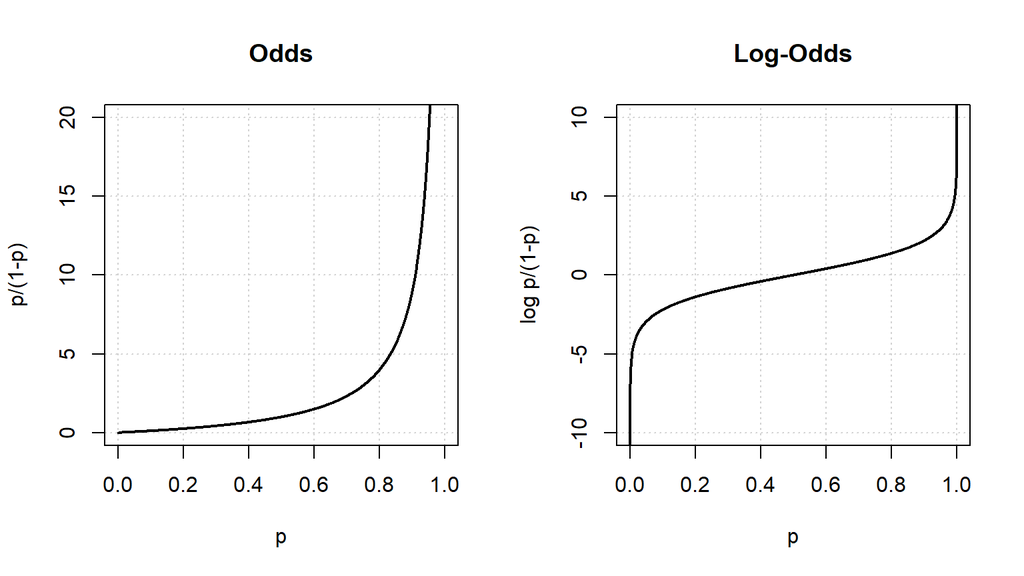

- Main idea is to use the real-valued linear combination of the explanatory variable $\vec{x_i}$ to predict the real-valued log-odds i.e.
  $$\log\frac{p_i}{1 - p_i} = \beta_0 + \beta_1
  x_{i1} + \dotsb + \beta_d x_{id}$$
- The transformation from probability $p_i$ to its log-odds is called the [**logit**](https://en.wikipedia.org/wiki/Logit) (as an abbreviation of “logistic unit”) function
  $$\text{logit}(p_i) = \log\frac{p_i}{1 -
  p_i}$$
  The logit function is invertible. Its inverse is the **expit** function
  $$p_i =
  \text{expit}(x)= \frac{e^x}{1+e^x}=\frac{1}{1+ e^{-x}}$$
- Expit function is monotonic increasing and squeezes the entire real number line $\mathbb{R}$ onto the $(0,1)$ interval. In general, such an S-shape curve is called a [**sigmoid function**](https://en.wikipedia.org/wiki/Sigmoid_function). (In machine learning, some people even refer to this expit function as “the” sigmoid function.)
- Fact: The derivative of the expit function is
  $$\frac{dp}{dx} = \frac{d}{dx}\text{expit}(x) =
  \frac{e^{-x}}{(1 + e^{-x})^2} = \left(\frac{1}{1 +
  e^{-x}}\right)\left(\frac{e^{-x}}{1 + e^{-x}}\right) =
  p(1-p)$$
- Expit (and also logit) function is symmetric in the sense that as $x\rightarrow -\infty$ or $x\rightarrow +\infty$, both $f(x)\rightarrow 0$ and $f(x)\rightarrow 1$ at the same rate.

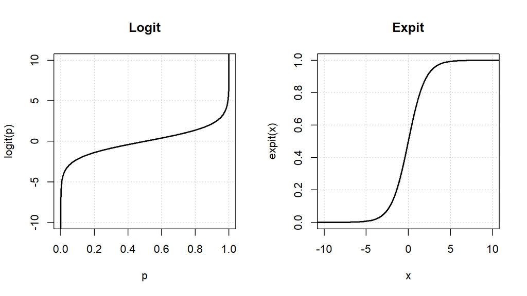

- Continuing the statistical model assumption:
  7. **Logit as link:** Combining the above together, the logistic regression model equation is
     $$\log\frac{p_i}{1 - p_i} = \text{logit}(p_i)
     = \beta_0 + \beta_1 x_{i1} + \dotsb + \beta_d x_{id}$$
     Equivalently, it is
     $$\underbrace{\mathbb{E}(Y_i)}_{\mu_i} =
     \underbrace{P(Y_i = 1)}_{p_i} = \underbrace{\text{expit}}_f(\beta_0 +
     \beta_1 x_{i1} + \dotsb + \beta_d x_{id}) = \frac{1}{1+ e^{-(\beta_0 +
     \beta_1 x_{i1} + \dotsb + \beta_d x_{id})}}$$
     (Technically, in statistics literature, our function $f = \text{expit}$ is not referred to as the link function. Instead, its inverse function $f^{-1} = \text{logit}$ is the link function.)
- In general, any S-shape sigmoid function $f:\mathbb{R}\mapsto(0,1)$ that squeezes the entire real number line $\mathbb{R}$ onto the $(0,1)$ interval can be used as a link function for logistic regression. In statistics literature, some other notable choices of link function are:
  1. [**Probit**](https://en.wikipedia.org/wiki/Probit)
     $$f(x) = \Phi(x) = \int_\infty^x\,
     \frac{1}{\sqrt{2\pi}} e^{-\frac{1}{2}z^2}\,dz$$
     This is just the cumulative distribution function CDF of the standard normal $\mathcal{N}(0,1)$ distribution. Using this link is called the [**probit regression**](https://en.wikipedia.org/wiki/Probit_model). It has an interpretation of some latent variable model that thresholds a normally distributed value as a binary response. (Don’t worry about it.) The profit link function $\Phi(x)$ is symmetric (like the logit link function previously). Since $\Phi(x)$ does not have a closed-form formula, it is slightly more expensive to compute than the logit link function.
  2. **Log-log** and **complementary log-log**
     $$f(x) = e^{-e^{-x}}\quad\text{and}\quad f(x)
     = 1 - e^{-e^{x}}$$
     These are the cumulative distribution function CDF of the log-[Weibull](https://en.wikipedia.org/wiki/Weibull_distribution) [extreme value distribution](https://en.wikipedia.org/wiki/Generalized_extreme_value_distribution) and its negative sibling. The log-log and complementary log-log link functions are asymmetric. For the complementary log-log link function, as $x\rightarrow -\infty$ or $x\rightarrow +\infty$, $f(x)\rightarrow 0$ at a slower rate than $f(x)\rightarrow 1$. On the other hand, for the log-log link function, $f(x)\rightarrow 0$ at a faster rate than $f(x)\rightarrow 1$. Therefore, these link functions are useful for modeling rare events whose probabilities of occurrence tend to be very small (or very large) e.g. survival analysis, hazard ratio.

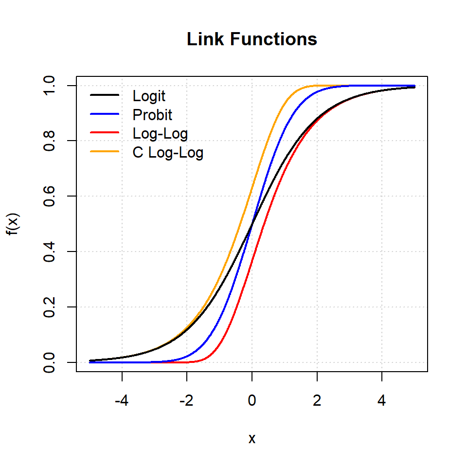

## 6.3 Likelihood Inference for ${\small \vec{\beta}}$, Log Loss

- Logistic regression with logit link function is the statistical model
  $$Y_i\sim\text{Bern}\bigg(\underbrace{\frac{1}{1+
  e^{-(\beta_0 + \beta_1 x_{i1} + \dotsb + \beta_d x_{id})}}}_{0 \,<\,
  p_i\, <\, 1}\bigg)\quad\text{for } i=1,\dotsc,n$$
  with parameters $\beta_0,\dotsc,\beta_d$.
- Given $n$ pairs of observed data points $(\vec{x}_1,y_1),\dotsc,(\vec{x}_n,y_n)$, we wish to “fit the best line / curve to the data” by choosing the optimal $\beta_0^*,\dotsc,\beta_d^*$ parameters. Since the model involves a non-linear link function, this “line” is not a straight line but a sigmoid curve.

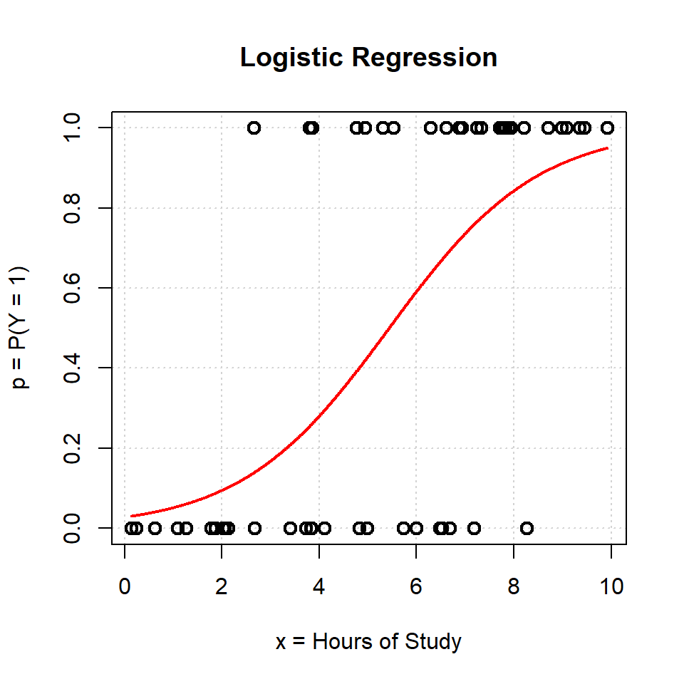

- How do the choices of $\beta_0,\dotsc,\beta_d$ parameters affect the resulting sigmoid curve? Let’s consider a simple case with only one explanatory variable $x$ i.e. $d=1$ so there are only the “intercept” $\beta_0$ and “slope” $\beta_1$ parameters. In this case, the model equation is
  $$P(Y_i=1) = p_i =
  \text{expit}(\beta_0 + \beta_1 x_i) = \frac{1}{1 + e^{-(\beta_0 +
  \beta_1 x_i)}}\quad\text{for } i=1,\dotsc,n$$
  Below are some illustrations with various choices of $\beta_0$ and $\beta_1$ parameters. In summary, $\beta_0$ controls the horizontal shift of the sigmoid curve and $\beta_1$ controls the steepness of the S-shape. (They are analogous to the concepts of intercept and slope in the case of a straight line.)

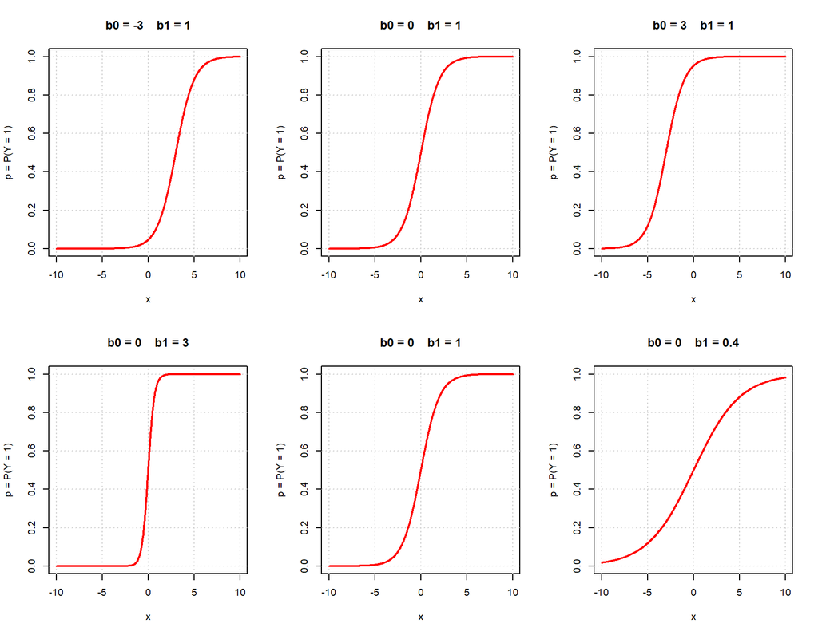

- To find the optimal $\beta_0^*,\dotsc,\beta_d^*$ parameters such that the fitted curve is “closest” to all observed data points, we will NOT use the mean squared error MSE to compare the observed binary response $y_i\in\{0,1\}$ vs the predicted probability of occurrence $p_i\in(0,1)$:
  $$\text{MSE} = \frac{1}{n}\sum_{i=1}^n(y_i -
  p_i)^2$$
  Why not?
  1. **Non-convex optimization:** For linear regression model, the MSE objective / loss / cost function is a quadratic function of the $\beta_0,\dotsc,\beta_d$ parameters and hence a [convex optimization](https://en.wikipedia.org/wiki/Convex_optimization) problem which is easy to optimize with unique global optimum $\beta_0^*,\dotsc,\beta_d^*$. On the other hand, for logistic regression with the logit link function, if we use MSE as the objective function, then the corresponding optimization problem is not convex so it can be difficult to solve numerically.
  2. **Non-linear perception of probability**: We tend to think of $p_i = 0.0001$ vs $p_i = 0.01$ as a $100 \times$ increase in the probability of occurrence of a rare event. On the other hand, $p_i = 0.5001$ vs $p_i = 0.51$ seem negligible.
  3. **Insufficient penalty for misclassification:** If the observed response $y_i = 1$ but the predicted probability $p_i\approx 0$, then we misclassify badly but only incur a penalty of $(y_i - p_i)^2 \approx 1$ which is often not severe enough.
- Instead, we follow the maximum likelihood principle to estimate the $\beta_0,\dotsc,\beta_d$ parameters. Recall the likelihood function for Bernoulli distribution is
  $$L(\beta_0,\dotsc,\beta_d) = \prod_{i=1}^n
  P(Y_i=y_i) = \prod_{i=1}^n p_i^{y_i} (1-p_i)^{1 -
  y_i}\quad\text{with}\quad p_i = \frac{1}{1+ e^{-(\beta_0 + \beta_1
  x_{i1} + \dotsb + \beta_d x_{id})}}$$
  Therefore, $L(\beta_0,\dotsc,\beta_d)$ is indeed a function of the $\beta_0,\dotsc,\beta_d$ parameters. Now the log-likelihood function is
  $$l(\beta_0,\dotsc,\beta_d) = \log
  L(\beta_0,\dotsc,\beta_d) = \sum_{i=1}^n y_i \log(p_i) +
  (1-y_i)\log(1-p_i)$$
  The maximum likelihood estimate MLE is
  $$\beta_0^*,\dotsc,\beta_d^* =
  \mathop{\mathrm{arg\,max}}_{\beta_0,\dotsc,\beta_d}
  l(\beta_0,\dotsc,\beta_d) =
  \mathop{\mathrm{arg\,max}}_{\beta_0,\dotsc,\beta_d} \sum_{i=1}^n y_i
  \log(p_i) + (1-y_i)\log(1-p_i)$$
- Why does maximizing the likelihood function make sense? The contribution of the $i^\text{th}$ data point $(\vec{x}_i, y_i)$ to the log-likelihood function $l(\beta_0,\dotsc,\beta_d)$ is
  $$y_i \log(p_i) + (1-y_i)\log(1-p_i) =
  \begin{cases}
  \log(p_i) & \text{if } y_i = 1\\
  \log(1-p_i) & \text{if } y_i = 0
  \end{cases}$$
  If $y_i = 1$, then the contribution is maximized when $p_i = 1$. Similarly for $y_i = 0$ and $p_i = 0$. So it encourages choosing $\beta_0,\dotsc,\beta_d$ parameters to bring $y_i\approx p_i$ close to each other. Moreover, the penalty of an overly-confident prediction mistake can be severe e.g. if $y_i = 1$ but $p_i\approx 0$, then $\log(p_i) \approx -\infty$.

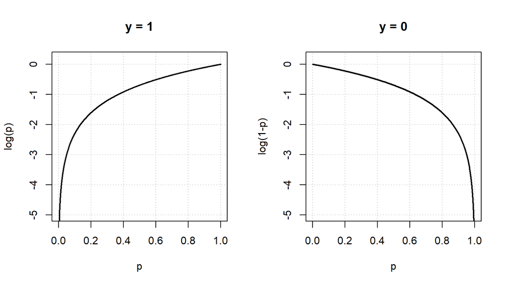

- In machine learning literature, the **log loss** / **cross-entropy loss** is
  $$\text{loss}(y, p) = -\left(y \log(p) +
  (1-y)\log(1-p)\right)$$
  It is the most common objective / loss / cost function for binary classification task. This is exactly the negative version of the log-likelihood function above i.e. maximizing for the MLE is same as minimizing the log loss.
- Although the MLE optimization problem
  $$\beta_0^*,\dotsc,\beta_d^*=
  \mathop{\mathrm{arg\,max}}_{\beta_0,\dotsc,\beta_d} \sum_{i=1}^n y_i
  \log(p_i) + (1-y_i)\log(1-p_i)$$
  is convex and thus must have a unique global optimum, there is unfortunately no closed-form solution (unlike the linear regression which has known explicit matrix formula for $\vec{\beta}_\text{MLE}$.)
- In practice, we solve this optimization using some iterative algorithm. For example, R’s `glm()` function uses the [iteratively reweighted least squares IRLS](https://en.wikipedia.org/wiki/Iteratively_reweighted_least_squares) / [Fisher](https://en.wikipedia.org/wiki/Fisher_information) [scoring](https://en.wikipedia.org/wiki/Scoring_algorithm) algorithm which is essentially the [Newton-Raphson method](https://en.wikipedia.org/wiki/Newton%27s_method). Other iterative approaches include [gradient descent](https://en.wikipedia.org/wiki/Gradient_descent) (which is popular within the machine learning community) and [L-BFGS](https://en.wikipedia.org/wiki/Limited-memory_BFGS).
- In R, use the `glm(..., family=binomial(...))` function to fit a logistic regression model (which is one kind of [generalized linear model GLM](https://en.wikipedia.org/wiki/Generalized_linear_model)).

```r
study <- c(0.13, 0.23, 0.62, 1.08, 1.26, 1.77, 1.86, 2.02, 2.06, 2.12,
           2.66, 2.67, 3.40, 3.72, 3.80, 3.82, 3.84, 3.86, 4.11, 4.77,
           4.82, 4.94, 4.98, 5.30, 5.53, 5.73, 6.00, 6.29, 6.47, 6.52,
           6.61, 6.68, 6.87, 6.93, 7.18, 7.24, 7.32, 7.70, 7.77, 7.83,
           7.89, 7.94, 8.21, 8.27, 8.70, 8.98, 9.08, 9.35, 9.45, 9.92)
exam <- c(0, 0, 0, 0, 0, 0, 0, 0, 0, 0,
          1, 0, 0, 0, 1, 0, 0, 1, 0, 1,
          0, 1, 0, 1, 1, 0, 0, 1, 0, 0,
          1, 0, 1, 1, 0, 1, 1, 1, 1, 1,
          1, 1, 1, 0, 1, 1, 1, 1, 1, 1) # 1 is pass and 0 is fail

model <- glm(exam ~ study, family = binomial) # Logit link is default. See ?family

# Link function
model$family$link # See str(model)

# Beta's
model
model$coefficients
coef(model)
coefficients(model)
summary(model)
```

```
[1] "logit"
```

```
Call:  glm(formula = exam ~ study, family = binomial)

Coefficients:
(Intercept)        study
    -3.5686       0.6563

Degrees of Freedom: 49 Total (i.e. Null);  48 Residual
Null Deviance:      69.31
Residual Deviance: 46.72    AIC: 50.72
```

```
(Intercept)       study
  -3.568573    0.656332
```

```
(Intercept)       study
  -3.568573    0.656332
```

```
(Intercept)       study
  -3.568573    0.656332
```

```
Call:
glm(formula = exam ~ study, family = binomial)

Coefficients:
            Estimate Std. Error z value Pr(>|z|)
(Intercept)  -3.5686     1.0652   -3.35 0.000808 ***
study         0.6563     0.1793    3.66 0.000252 ***
---
Signif. codes:  0 '***' 0.001 '**' 0.01 '*' 0.05 '.' 0.1 ' ' 1

(Dispersion parameter for binomial family taken to be 1)

    Null deviance: 69.315  on 49  degrees of freedom
Residual deviance: 46.716  on 48  degrees of freedom
AIC: 50.716

Number of Fisher Scoring iterations: 5
```

- In `glm(..., family=binomial)`, if the response variable is a logical vector of `TRUE` / `FALSE` values, then it would also be viewed as 1’s and 0’s. If the response variable is an R’s `factor`, then its first level is viewed as 0 and all other levels are viewed as 1. For example, `'success'` is 1 and `'failure'` is 0 based on alphabetical order.

```r
# Same data as previously
study <- c(0.13, 0.23, 0.62, 1.08, 1.26, 1.77, 1.86, 2.02, 2.06, 2.12,
           2.66, 2.67, 3.40, 3.72, 3.80, 3.82, 3.84, 3.86, 4.11, 4.77,
           4.82, 4.94, 4.98, 5.30, 5.53, 5.73, 6.00, 6.29, 6.47, 6.52,
           6.61, 6.68, 6.87, 6.93, 7.18, 7.24, 7.32, 7.70, 7.77, 7.83,
           7.89, 7.94, 8.21, 8.27, 8.70, 8.98, 9.08, 9.35, 9.45, 9.92)
exam <- c('f', 'f', 'f', 'f', 'f', 'f', 'f', 'f', 'f', 'f',
          'p', 'f', 'f', 'f', 'p', 'f', 'f', 'p', 'f', 'p',
          'f', 'p', 'f', 'p', 'p', 'f', 'f', 'p', 'f', 'f',
          'p', 'f', 'p', 'p', 'f', 'p', 'p', 'p', 'p', 'p',
          'p', 'p', 'p', 'f', 'p', 'p', 'p', 'p', 'p', 'p') # 'p' is pass and 'f' is fail

# Verify the default (alphabetical) ordering of levels
levels(factor(exam))
```

```
[1] "f" "p"
```

```r
glm(factor(exam) ~ study, family = binomial) # Same model as previously
```

```
Call:  glm(formula = factor(exam) ~ study, family = binomial)

Coefficients:
(Intercept)        study
    -3.5686       0.6563

Degrees of Freedom: 49 Total (i.e. Null);  48 Residual
Null Deviance:      69.31
Residual Deviance: 46.72    AIC: 50.72
```

- There are two other ways to format the response variable in `glm(..., family=binomial)` for grouped data (later).
- Interpretation of coefficient $\beta_j$: If $x_j$ increases by $+1$ unit to become $x_j + 1$ while all other explanatory variables do not change, then the odds become
  $$\underbrace{\frac{p^\text{new}_i}{1 -
  p^\text{new}_i}}_\text{new odds} = e^{\beta_0 + \beta_1 x_{i1} + \dotsb
  + \beta_j(x_{ij} + 1) + \dotsb \beta_d x_{id}} =
  \underbrace{\frac{p^\text{old}_i}{1 - p^\text{old}_i}}_\text{old odds}
  \times e^{\beta_j}$$
- This does not mean the probability $p_i$ itself changes by a constant amount of $e^{\beta_j}$. The amount of change in $p_i$ depends on the specific initial $\vec{x}_i$ value.

```r
b0 <- 0
b1 <- 1

x <- c(0, 1) # From 0 to 1
(p <- 1 / (1 + exp(-(b0 + b1 * x))))

x <- c(3, 4) # From 3 to 4
(p <- 1 / (1 + exp(-(b0 + b1 * x))))
```

```
[1] 0.5000000 0.7310586
[1] 0.9525741 0.9820138
```

- Many topics from linear regression continue to apply to logistic regression e.g. invariance of the model to affine transformation of an explanatory variable $x_j \mapsto a + b x_j$, one-hot encoding of categorical variable, interaction term, variable transformation / feature engineering e.g. polynomial, multicollinearity, and variance inflation factor VIF.
- Fisher scoring algorithm usually converges very quickly to the optimal $\vec{\beta}_\text{MLE}$ after only a small number of iterations.
- However, ironically if the data points are [**linearly separable**](https://en.wikipedia.org/wiki/Linear_separability), then Fisher scoring algorithm would never converge even after a large number of (R’s default is 25) iterations. In this case, besides R’s warning message, the `Std. Error` of the estimated coefficients shown in the model’s `summary()` tend to be very large. Numerically, the reason for non-convergence is because the “slope” parameter $\beta_1\rightarrow \infty$ or $-\infty$ increases without bound in order to make the slope of the sigmoid curve even steeper (or more vertical) so it could fit the data points even better.

```r
study <- c(0.11, 0.22, 1.07, 1.27, 1.87, 2.67, 2.68, 3.85, 3.87, 4.83,
           5.28, 5.51, 6.46, 6.53, 7.23, 8.22, 8.29, 9.06, 9.47, 9.90)
midterm <- c(0, 0, 0, 0, 0, 0, 0, 0, 0, 0,
             1, 1, 1, 1, 1, 1, 1, 1, 1, 1) # 1 is pass and 0 is fail
```

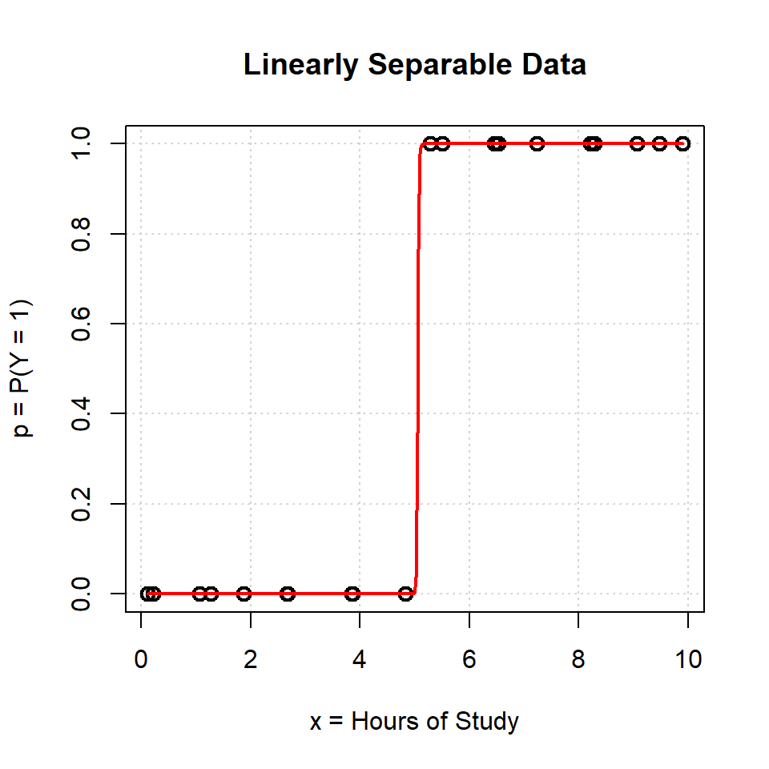

```r
model <- glm(midterm ~ study, family = binomial)

summary(model)
model$iter # Fisher scoring number of iteration
model$converged # Fisher scoring converged or not?
```

```
Warning: glm.fit: algorithm did not converge
```

```
Call:
glm(formula = midterm ~ study, family = binomial)

Coefficients:
             Estimate Std. Error z value Pr(>|z|)
(Intercept)   -458.30  259786.19  -0.002    0.999
study           90.65   51230.16   0.002    0.999

(Dispersion parameter for binomial family taken to be 1)

    Null deviance: 2.7726e+01  on 19  degrees of freedom
Residual deviance: 5.5508e-09  on 18  degrees of freedom
AIC: 4

Number of Fisher Scoring iterations: 25

[1] 25
[1] FALSE
```

## 6.4 Prediction

- R has various functionalities to compute both fitted / predicted probability value $\hat{p}_i$ and its corresponding linear combination $\beta_0^* + \beta_1^* x_1 + \dotsb + \beta_d^* x_d$ before the link function.

```r
study <- c(0.13, 0.23, 0.62, 1.08, 1.26, 1.77, 1.86, 2.02, 2.06, 2.12,
           2.66, 2.67, 3.40, 3.72, 3.80, 3.82, 3.84, 3.86, 4.11, 4.77,
           4.82, 4.94, 4.98, 5.30, 5.53, 5.73, 6.00, 6.29, 6.47, 6.52,
           6.61, 6.68, 6.87, 6.93, 7.18, 7.24, 7.32, 7.70, 7.77, 7.83,
           7.89, 7.94, 8.21, 8.27, 8.70, 8.98, 9.08, 9.35, 9.45, 9.92)
exam <- c(0, 0, 0, 0, 0, 0, 0, 0, 0, 0,
          1, 0, 0, 0, 1, 0, 0, 1, 0, 1,
          0, 1, 0, 1, 1, 0, 0, 1, 0, 0,
          1, 0, 1, 1, 0, 1, 1, 1, 1, 1,
          1, 1, 1, 0, 1, 1, 1, 1, 1, 1) # 1 is pass and 0 is fail

model <- glm(exam ~ study, family = binomial)

# Fitted values / predictions (for probability p_i)
fitted(model)
fitted.values(model)
model$fitted.values
```

```
         1          2          3          4          5          6
0.02979261 0.03174943 0.04063481 0.05418033 0.06056313 0.08265070
         1          2          3          4          5          6
0.02979261 0.03174943 0.04063481 0.05418033 0.06056313 0.08265070
         1          2          3          4          5          6
0.02979261 0.03174943 0.04063481 0.05418033 0.06056313 0.08265070
```

```r
# Fitted linear predictor i.e. b0 + b1*x1 + ... + b_d*x_d before link function
b0 <- coef(model)[1]
b1 <- coef(model)[2]
b0 + b1 * study

model$linear.predictors
```

```
[1] -3.483249 -3.417616 -3.161647 -2.859734 -2.741594 -2.406865
        1         2         3         4         5         6
-3.483249 -3.417616 -3.161647 -2.859734 -2.741594 -2.406865
```

```r
# Compute fitted probability p_i after logit link
1 / (1 + exp(-model$linear.predictors))
```

```
         1          2          3          4          5          6
0.02979261 0.03174943 0.04063481 0.05418033 0.06056313 0.08265070
```

- Similarly, given a new explanatory variable value, R’s `predict()` function can output either the `'response'` probability $p_i$ or its corresponding linear combination before `'link'` function.

```r
x.new <- 3

b0 + b1 * x.new
(u <- predict(model, newdata=data.frame(study=x.new), type='link')) # b0 + b1*x1 + ... + b_d*x_d
```

```
(Intercept)
  -1.599577
        1
-1.599577
```

```r
1 / (1 + exp(-u)) # Compute logit link
predict(model, newdata=data.frame(study=x.new), type='response') # p_i
```

```
        1
0.1680408
        1
0.1680408
```

- Recall both logit and probit link functions are symmetric around their two tails. Although the probit link $\Phi(x)\rightarrow 0$ or $1$ as $x\rightarrow\pm\infty$ at a faster rate than the logit link, in practice they yield very similar models and predictions.
- On the other hand, use asymmetric log-log or complementary log-log links only if the data exhibit such asymmetry.

```r
logit.model <- glm(exam ~ study, family = binomial(link='logit'))
probit.model <- glm(exam ~ study, family = binomial(link='probit'))
cloglog.model <- glm(exam ~ study, family = binomial(link='cloglog'))
```

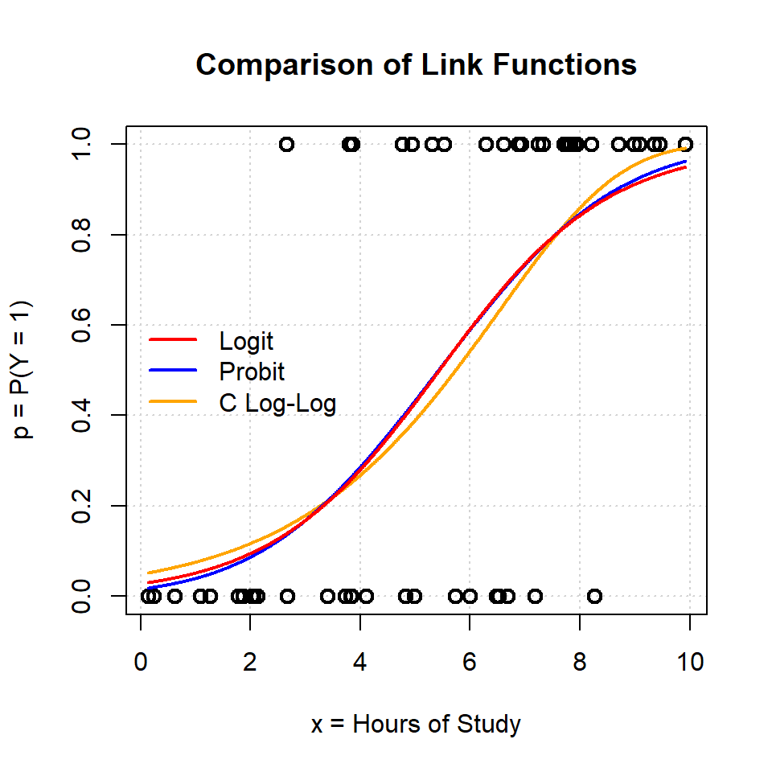

## 6.5 Confusion Matrix

- Logistic regression model only outputs / predicts the probability $\hat{p}_i = P(Y_i = 1)$ of occurrence and not an actual binary class label $\hat{y}_i\in \{0,1\}$. To do so, we need to choose a threshold $0 < \tau < 1$ to truncate the probability value i.e.
  $$\hat{y}_i =
  \begin{cases}
  1 & \text{if } \hat{p}_i > \tau\\
  0 & \text{if } \hat{p}_i \leq \tau
  \end{cases}$$

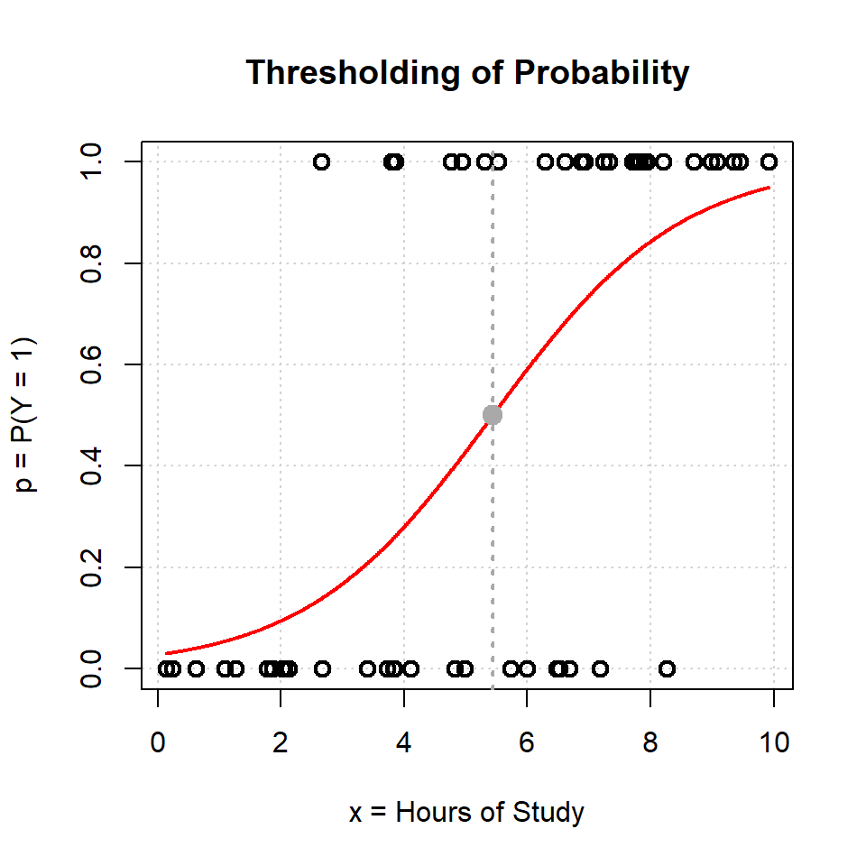

- A [**confusion matrix**](https://en.wikipedia.org/wiki/Confusion_matrix) is a $2\times 2$ [contingency table](https://en.wikipedia.org/wiki/Contingency_table) to tabulate the observed responses $y_i$ vs the predicted labels $\hat{y}_i$ in a data set.

```r
tau <- 0.5
y.hat <- as.numeric(fitted(model) > tau) # Convert TRUE/FALSE to 0/1

(confusion.matrix <- table(exam, y.hat))
```

```
    y.hat
exam  0  1
   0 18  7
   1  6 19
```

- In machine learning, the most important metrics from a confusion matrix are:
  - Accuracy / error rate / misclassification rate
  - [**True positive rate** TPR](https://en.wikipedia.org/wiki/True_positive_rate) and [**false positive rate** FPR](https://en.wikipedia.org/wiki/False_positive_rate): For [receiver operating characteristic ROC](https://en.wikipedia.org/wiki/Receiver_operating_characteristic) curve and its [area under curve AUC](https://en.wikipedia.org/wiki/Receiver_operating_characteristic#Area_under_the_curve) metric.
  - [**Precision**](https://en.wikipedia.org/wiki/Precision_and_recall) and [**recall**](https://en.wikipedia.org/wiki/Precision_and_recall): For precision-recall curve and [$F_1$-score](https://en.wikipedia.org/wiki/F-score). These are particularly useful for label-imbalanced data set e.g. fraud detection, rare disease.

```r
n <- sum(confusion.matrix) # Total number of data points
tn <- confusion.matrix[1,1] # True negative
fp <- confusion.matrix[1,2] # False positive
fn <- confusion.matrix[2,1] # False negative
tp <- confusion.matrix[2,2] # True positive

(accuracy <- (tp + tn) / n) # Accuracy = 1 - error (or misclassification) rate
(tpr <- tp / (tp + fn)) # True positive rate = recall
(fpr <- fp / (fp + tn)) # False positive rate
(precision <- tp / (tp + fp)) # Precision
```

```
[1] 0.74
[1] 0.76
[1] 0.28
[1] 0.7307692
```

- *Example:* For email spam filtering as a binary classificiation task i.e. $y\in\{1=\text{spam}, 0=\text{good}\}$:
  - Accuracy: Out of all emails, how many are classified correctly?
  - True positive rate TPR / recall: Out of all truly spam emails, how many are flagged as spam correctly?
  - False positive rata FPR: Out of all truly good emails, how many are flagged as spam incorrectly?
  - Precision: Out of all emails that are flagged as spam, how many are truly spam emails?
- Choice of threshold $\tau$ is not necessarily always $1/2$. It should be a business decision (rather than a scientific decision) based on the risk of false positive vs false negative error.
- As $\tau$ increases from $0$ to $1$, it becomes more conservative / reluctant to classify a data point as $\hat{y}_i = 1$ unless its probability $\hat{p}_i$ is sufficiently high. In doing so:
  - More data points are classified as $\hat{y}_i = 0$ i.e. negative.
  - Accuracy could increase or decrease i.e. it could make fewer or more misclassification errors. This is a trade-off between false positive FP vs false negative FN mistakes.
  - Both true positive rate TPR (i.e. recall) and false positive rate FPR must decrease.
  - Precision could increase or decrease. But as $\tau\approx 1$, precision usually $\approx 1$.

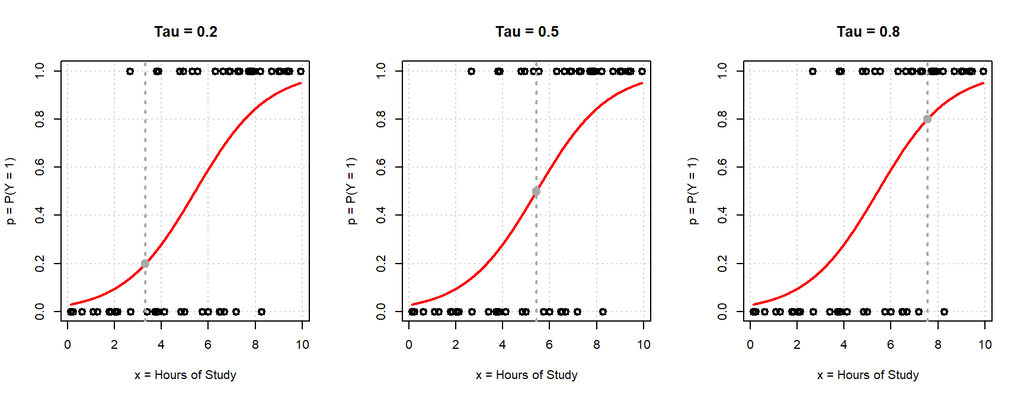

```r
for (tau in c(0.2, 0.5, 0.8)) {
  y.hat <- as.numeric(fitted(model) > tau)
  confusion.matrix <- table(exam, y.hat)
  ...
  c(accuracy, tpr, fpr, precision)
}
```

```
# tau <- 0.2
    y.hat
exam  0  1
   0 11 14
   1  1 24
[1] 0.7000000 0.9600000 0.5600000 0.6315789
```

```
# tau <- 0.5
    y.hat
exam  0  1
   0 18  7
   1  6 19
[1] 0.7400000 0.7600000 0.2800000 0.7307692
```

```
# tau <- 0.8
    y.hat
exam  0  1
   0 24  1
   1 13 12
[1] 0.7200000 0.4800000 0.0400000 0.9230769
```

## 6.6 Decision Boundary

- Each threshold $\tau$ value induces a linear [**decision boundary**](https://en.wikipedia.org/wiki/Decision_boundary). To understand this linearity, note a choice of threshold $\tau$ on the probability $p_i$
  $$\tau < p_i =\frac{1}{1+ e^{-(\beta_0 + \beta_1
  x_{i1} + \dotsb + \beta_d x_{id})}}$$
  is equivalent to another related threshold on the linear combination of explanatory variables itself i.e.
  $$\underbrace{\log\frac{\tau}{1 -
  \tau}}_\text{another threshold} < \beta_0 + \beta_1 x_{i1} + \dotsb +
  \beta_d x_{id}$$
  This last equation represents a (linear) line / plane / (high-dimensional) [hyperplane](https://en.wikipedia.org/wiki/Hyperplane) in $\mathbb{R}^d$ where $\vec{x}_i=(x_{i1}, \dotsc, x_{id})$ sits.
- It is easier to visualize such linear decision boundary in the case with just two continuous explanatory variables $x_1$ and $x_2$ so the “input space” is the $\mathbb{R}^2$ plane.
- *Example:* Let $x_1\in[0,\infty)$ be the number of hours of studying, $x_2\in[0, 100]$ be the midterm score, and $y\in\{\text{pass},\text{fail}\}$ is the outcome of the final exam.

```r
data <- data.frame(study=c(5.86, 0.09, 2.94, 2.77, 8.14, 2.60, 7.24, 9.06, 9.49, 0.73,
                           7.55, 2.86, 1.00, 9.54, 4.16, 4.55, 9.71, 5.84, 9.62, 7.62,
                           7.15, 9.97, 5.06, 4.90, 6.49, 8.31, 4.82, 8.42, 5.14, 5.30,
                           5.67, 2.39, 8.78, 6.55, 4.82, 9.71, 4.60, 6.22, 3.88, 0.07,
                           9.38, 2.42, 5.66, 1.81, 9.04, 0.84, 9.01, 8.92, 7.23, 5.65),
                   midterm=c(39, 75, 90, 81, 82, 42, 18, 17, 89, 74,
                             56, 7, 85, 91, 23, 63, 7, 51, 81, 97,
                             34, 63, 41, 35, 82, 69, 32, 44, 26, 13,
                             91, 71, 57, 92, 90, 6, 5, 99, 21, 93,
                             19, 13, 54, 27, 35, 8, 77, 44, 4, 70),
                   exam=c(0, 0, 1, 1, 1, 0, 1, 1, 1, 1,
                          1, 0, 0, 1, 0, 1, 1, 0, 1, 1,
                          1, 1, 1, 0, 1, 1, 1, 1, 0, 0,
                          1, 0, 1, 1, 1, 0, 0, 1, 0, 0,
                          1, 0, 1, 1, 1, 0, 1, 0, 0, 1)) # 1 is pass and 0 is fail
```

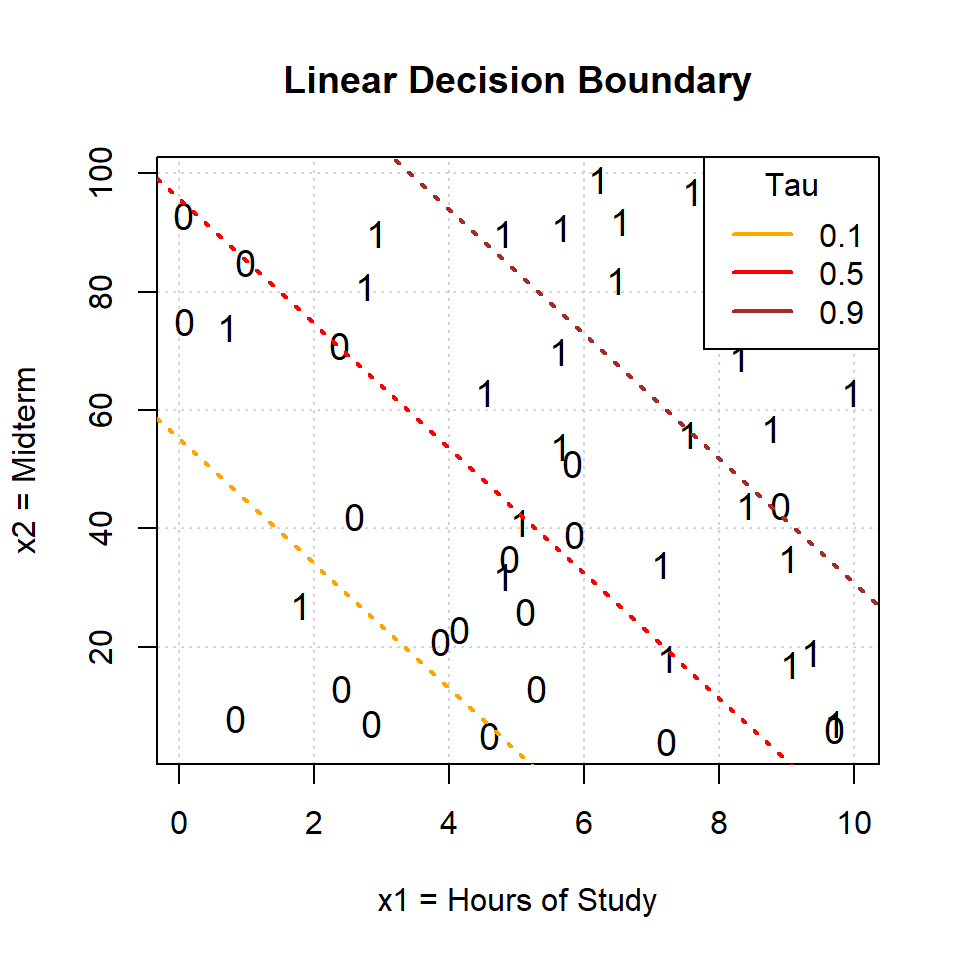

```r
# Fit logistic regression model to estimate beta coefficients
model <- glm(exam ~ study + midterm, family = binomial, data = data)
b0 <- coef(model)[1]
b1 <- coef(model)[2]
b2 <- coef(model)[3]

# Plot data points with labels
with(data, {
  plot(study, midterm, type='n')
  text(study, midterm, exam)
})

# Plot linear decision boundary in (x1,x2)-space
tau <- 0.5
abline((log(tau / (1 - tau)) - b0) / b2, - b1 / b2, col='red', lty=3)
```

```
Call:  glm(formula = exam ~ study + midterm, family = binomial, data = data)

Coefficients:
(Intercept)        study      midterm
   -5.18982      0.57241      0.05421

Degrees of Freedom: 49 Total (i.e. Null);  47 Residual
Null Deviance:      66.41
Residual Deviance: 40.25    AIC: 46.25
```

- Logistic regression is indeed a linear model for binary classification because its decision boundary is linear.

## 6.7 Grouped vs Ungrouped Data

- In traditional statistics, logistic regression is often taught in the context of categorical data analysis in which all explanatory variables $x_i$’s are categorical i.e. no continuous / quantitative $x_i$. Many of the statistical inference and hypothesis testing techniques (later) are valid only in this scenario.
- *Example:* Let $x\in\{1,\dotsc,5\}$ be the star rating of a hotel (viewed as a categorical variable and not a quantitative variable) and $y\in\{\text{tidy}, \text{not tidy}\}$ be a guest’s review sentiment about tidiness.

```r
hotel <- data.frame(star=c(1, 1, 1, 1, 1, 1, 1, 1, 1, 1,
                           2, 2, 2, 2, 2, 2, 2, 2, 2, 2,
                           3, 3, 3, 3, 3, 3, 3, 3, 3, 3,
                           4, 4, 4, 4, 4, 4, 4, 4, 4, 4,
                           5, 5, 5, 5, 5, 5, 5, 5, 5, 5),
                    tidy=c(0, 0, 0, 1, 0, 0, 0, 1, 0, 0,
                           1, 0, 0, 0, 1, 0, 0, 1, 0, 1,
                           0, 1, 0, 1, 1, 0, 0, 1, 0, 1,
                           1, 0, 1, 1, 0, 1, 1, 0, 1, 1,
                           1, 1, 1, 0, 1, 1, 1, 1, 1, 1)) # 1 is tidy and 0 is not

head(hotel) # Long format i.e. one row per "review" observation unit
```

```
  star tidy
1    1    0
2    1    0
3    1    0
4    1    1
5    1    0
6    1    0
```

- R’s `library(reshape2)` package provides `cast()` and `melt()` functions to convert data from long format to wide format (and vice versa).
  - **Long format**: Each row is one individual unit of observation / occurrence.
  - **Wide format**: Each row is one grouping of multiple individual observations that share a common scenario / context i.e. a particular combination of explanatory variable values.

```r
library(reshape2)

(hotel.w <- dcast(hotel, star ~ tidy)) # Wide format i.e. one row per "star rating" group
```

```
  star 0 1
1    1 8 2
2    2 6 4
3    3 5 5
4    4 3 7
5    5 1 9
```

- By summing all binary responses together per each combination of categorical level of the explanatory variables, the logistic regression can now be viewed with binomial distribution instead of Bernoulli distribution i.e. the statistical model becomes
  $$Y_i\sim\text{Binom}\bigg(n_i\,,
  \underbrace{\frac{1}{1+ e^{-(\beta_0 + \beta_1 x_{i1} + \dotsb + \beta_d
  x_{id})}}}_{0 \,<\, p_i\, <\, 1}\bigg)\quad\text{for }
  i=1,\dotsc,k$$
  Here we have:
  - $k$ is the number of groups. Each group corresponds to a distinct explanatory variable value $\vec{x}_i$.
  - $n_i$ is the number of observations of the $i^\text{th}$ group.
  - Total number of observations is still
    $$n_1 + \dotsb + n_k = n$$
  - $Y_i\in\{0,\dotsc,n_i\}$ is the number of success among the $n_i$ number of observations of the $i^\text{th}$ group. It is a sum of $n_i$ independent Bernoulli random variables. Therefore, $Y_i$ is a binomial random variable.
- The likelihood function for binomial distribution is
  $$L(\beta_0,\dotsc,\beta_d) = \prod_{i=1}^k
  P(Y_i=y_i) = \prod_{i=1}^k \binom{n_i}{y_i} p_i^{y_i} (1-p_i)^{n_i -
  y_i}\quad\text{with}\quad p_i = \frac{1}{1+ e^{-(\beta_0 + \beta_1
  x_{i1} + \dotsb + \beta_d x_{id})}}$$
  The log-likelihood function is
  $$l(\beta_0,\dotsc,\beta_d) = \log
  L(\beta_0,\dotsc,\beta_d) = \underbrace{\sum_{i=1}^k y_i \log(p_i) +
  (n_i-y_i)\log(1-p_i)}_\text{numerically same as Bernoulli case} +
  \underbrace{\sum_{i=1}^k \log\binom{n_i}{y_i}}_\text{constant}$$
  Therefore, the maximum likelihood estimate MLE
  $$\beta_0^*,\dotsc,\beta_d^* =
  \mathop{\mathrm{arg\,max}}_{\beta_0,\dotsc,\beta_d}
  l(\beta_0,\dotsc,\beta_d)$$
  yields exactly the same estimated coefficients $\vec{\beta}^*_\text{MLE}$ as the previous Bernoulli formulation.
- Note this binomial formulation is based on grouping of data points that share the same explanatory variable value $\vec{x}_i$. If some explanatory variable $x_{ij}\in\mathbb{R}$ is quantitative, then it is likely that each data point has a different value for $x_{ij}$. In this case, each group only has $n_i = 1$ data point i.e. ungrouped.
- R’s `glm(..., family=binomial)` function provides two more ways to represent the response variable in the model formula for grouped data.

```r
# Method 1 (Ungrouped): One column of 1's and 0's per observation
summary(glm(tidy ~ star, family = binomial, data = hotel))
```

```
Call:
glm(formula = tidy ~ star, family = binomial, data = hotel)

Coefficients:
            Estimate Std. Error z value Pr(>|z|)
(Intercept)  -2.1976     0.8052  -2.729  0.00635 **
star          0.8024     0.2556   3.139  0.00170 **
---
Signif. codes:  0 '***' 0.001 '**' 0.01 '*' 0.05 '.' 0.1 ' ' 1

(Dispersion parameter for binomial family taken to be 1)

    Null deviance: 68.994  on 49  degrees of freedom
Residual deviance: 56.445  on 48  degrees of freedom
AIC: 60.445

Number of Fisher Scoring iterations: 4
```

```r
# Method 2 (Grouped): Two-column matrix of counts of 1's and 0's per group
n <- hotel.w[,'1'] + hotel.w[,'0'] # Group size n_i
y <- hotel.w[,'1']
cbind(y, n - y)

summary(glm(cbind(y, n - y) ~ star, family = binomial, data = hotel.w))
```

```
     y
[1,] 2 8
[2,] 4 6
[3,] 5 5
[4,] 7 3
[5,] 9 1

Call:
glm(formula = cbind(y, n - y) ~ star, family = binomial, data = hotel.w)

Coefficients:
            Estimate Std. Error z value Pr(>|z|)
(Intercept)  -2.1976     0.8052  -2.729  0.00635 **
star          0.8024     0.2556   3.139  0.00170 **
---
Signif. codes:  0 '***' 0.001 '**' 0.01 '*' 0.05 '.' 0.1 ' ' 1

(Dispersion parameter for binomial family taken to be 1)

    Null deviance: 12.9442  on 4  degrees of freedom
Residual deviance:  0.3946  on 3  degrees of freedom
AIC: 16.898

Number of Fisher Scoring iterations: 3
```

```r
# Method 3 (Grouped): One column of proportion of 1's per group
(hotel.p <- data.frame(star=hotel.w$star,
                       n=hotel.w[,'0'] + hotel.w[,'1'],
                       y=hotel.w[,'1'] / (hotel.w[,'0'] + hotel.w[,'1'])))

summary(glm(y ~ star, family = binomial, data = hotel.p, weights = n))
```

```
  star  n   y
1    1 10 0.2
2    2 10 0.4
3    3 10 0.5
4    4 10 0.7
5    5 10 0.9

Call:
glm(formula = y ~ star, family = binomial, data = hotel.p, weights = n)

Coefficients:
            Estimate Std. Error z value Pr(>|z|)
(Intercept)  -2.1976     0.8052  -2.729  0.00635 **
star          0.8024     0.2556   3.139  0.00170 **
---
Signif. codes:  0 '***' 0.001 '**' 0.01 '*' 0.05 '.' 0.1 ' ' 1

(Dispersion parameter for binomial family taken to be 1)

    Null deviance: 12.9442  on 4  degrees of freedom
Residual deviance:  0.3946  on 3  degrees of freedom
AIC: 16.898

Number of Fisher Scoring iterations: 3
```

- All three usages of `glm(..., family=binomial)` yield the same coefficients $\vec{\beta}^*_\text{MLE}$ and hence the same model equation / fitted values / predictions / residuals.
- On the other hand, the number of observations (in the sense of the number of $Y_i$ random variables or the number of terms that appear in the likelihood function) reduces from $n$ ungrouped individual observations to $k$ groups. This has implication on the degrees of freedom of the model and its deviance values (later).
- In machine learning, modeling often involves at least one continuous / quantitative explanatory variable. Therefore, the data points are often not group-able.

## 6.8 Residual

- Generalized linear model GLM (such as logistic regression) has a few kinds of residual.
- **Response residual**: Simple difference between the observed binary outcome $y_i\in\{0,1\}$ vs the predicted probability $\hat{p}_i$.
  $$r_i^\text{response} = y_i - \hat{p}_i$$
  - Easy to interpret. Same computation as linear regression.
  - However, these residuals are not on the same scale of magnitude (i.e. not standardized nor have constant variance) across the data set. For example, if $\hat{p}_i\approx 0$ or $1$, then $|y_i - \hat{p}_i|$ tends to be smaller. On the other hand, $|y_i - \hat{p}_i|$ tends to be larger if $\hat{p}_i\approx 1/2$.

```r
# Response residual
p <- fitted(model)

y - p
residuals(model, type='response') # See ?residuals.glm
```

```
          1           2           3           4           5           6
-0.02979261 -0.03174943 -0.04063481 -0.05418033 -0.06056313 -0.08265070
          1           2           3           4           5           6
-0.02979261 -0.03174943 -0.04063481 -0.05418033 -0.06056313 -0.08265070
```

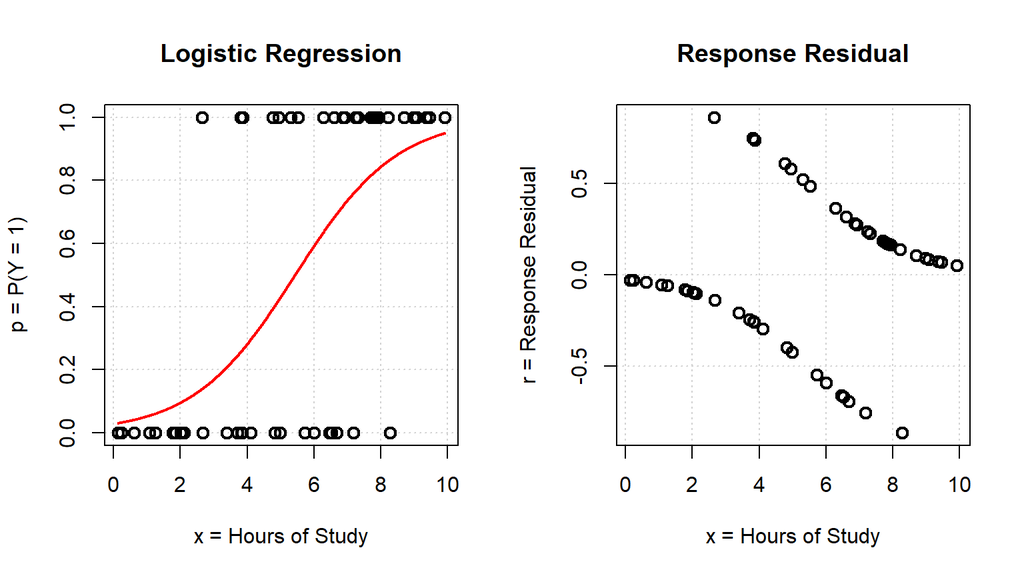

- **Pearson residual**: Attempt to standardize the response residual by dividing by its (estimated) standard error.
  $$r_i^\text{pearson} = \frac{y_i -
  \hat{p}_i}{\sqrt{\hat{p}_i (1-\hat{p}_i)}}\quad\text{for
  ungrouped}\quad\quad\text{and}\quad\quad r_i^\text{pearson} = \frac{y_i
  - n_i \hat{p}_i}{\sqrt{n_i \hat{p}_i (1-\hat{p}_i)}}\quad\text{for
  grouped}$$
  - For grouped data, if each group size $n_i$ is sufficiently large and each probability $p_i\not\approx0$ or $1$ is not too extreme, then the Pearson residuals are approximately $\mathcal{N}(0,1)$ normally distributed. (This is an example of **asymptotics** or **regularity condition** in statistics literature.) In this case, there are some proper statistical hypothesis testing techniques that use the Pearson residuals for model diagnostic.
  - For ungrouped data, the Pearson residuals are NOT necessarily approximately normally distributed (even for large number $n$ of data points). Nonetheless, a Pearson residual $|r^\text{pearson}_i|\gg 2$ of large magnitude is worth investigating.

```r
# Pearson residual
residuals(model, type='pearson')
(y - p) / sqrt(p * (1 - p))
```

```
         1          2          3          4          5          6
-0.1752355 -0.1810815 -0.2058056 -0.2393407 -0.2539045 -0.3001621
         1          2          3          4          5          6
-0.1752355 -0.1810815 -0.2058056 -0.2393407 -0.2539045 -0.3001621
```

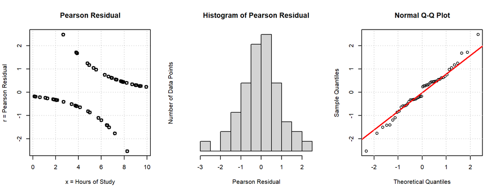

```r
# Deviance residual
residuals(model) # Default  Same as resid(model)
residuals(model, type='deviance')
summary(model)$deviance.resid
```

```
         1          2          3          4          5          6
-0.2459489 -0.2540251 -0.2880398 -0.3337764 -0.3534817 -0.4153720
         1          2          3          4          5          6
-0.2459489 -0.2540251 -0.2880398 -0.3337764 -0.3534817 -0.4153720
         1          2          3          4          5          6
-0.2459489 -0.2540251 -0.2880398 -0.3337764 -0.3534817 -0.4153720
```

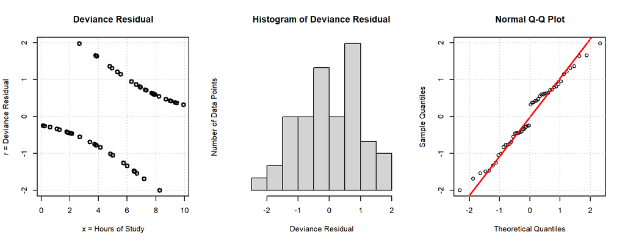

- **Working residual**: This is a byproduct from the internal computation at the final iteration of the Fisher scoring algorithm. (Don’t worry about it.)

```r
# Working residual
residuals(model, type='working')
model$residuals
```

```
        1         2         3         4         5         6
-1.030707 -1.032791 -1.042356 -1.057284 -1.064467 -1.090097
        1         2         3         4         5         6
-1.030707 -1.032791 -1.042356 -1.057284 -1.064467 -1.090097
```

- Linear regression can be viewed as a generalized linear model GLM with Gaussian distribution family i.e. `glm(..., family = gaussian)` in R. In this case, all four kinds of residual above are numerically the same. (Therefore, we did not need to introduce them separately before.)
- For logistic regression, the Pearson residual and deviance residual are different but usually similar numerically. Deviance residual has nicer statistical properties than Pearson residual.
- There are other kinds of further **standardized** / [**studentized**](https://en.wikipedia.org/wiki/Studentized_residual) Pearson and deviance residual in the forms
  $$r_i^\text{std pearson} =
  \frac{r_i^\text{pearson}}{\sqrt{1 - h_i}}\quad\quad\text{and}\quad\quad
  r_i^\text{std deviance} = \frac{r_i^\text{deviance}}{\sqrt{1 -
  h_i}}$$
  with some **leverage** value $h_i$. See R’s `rstandard()` and `rstudent()` documentation. (Don’t worry about these.)
- Recall that many statistcal properties about residual only hold for grouped data with large group size $n_i\gg 1$. In machine learning, data set is often ungrouped. In practice, we compute residuals and inspect their magnitudes but usually do not focus on performing statistical analysis on them.

## 6.9 Deviance and Goodness-of-Fit

- For linear regression, the coefficient of determination $R^2$ is one way to measure the goodness-of-fit of a fitted model. Does generalized linear model GLM (such as logistic regression) have such a measure? (Yes for grouped data.)
- Previously, we have
  $$\underbrace{SS_\text{total}=\sum_{i=1}^n (y_i -
  \bar{y})^2}_{SS_\text{null}} \quad > \quad
  \underbrace{SS_\text{error}=\sum_{i=1}^n (y_i -
  \hat{y}_i)^2}_{SS_\text{model}} \quad > \quad \underbrace{0 =
  \sum_{i=1}^n(y_i - y_i)^2}_{SS_\text{saturated}}$$
  Here we rename $SS_\text{total}$ as $SS_\text{null}$ to represent the null model which always predicts by overall mean $\bar{y}$. Similarly, we rename $SS_\text{error}$ as $SS_\text{model}$ to represent the fitted model of interest.
- A **saturated** model is a prefect model that does not produce any error / mistake. For the $i^\text{th}$ observed data point $y_i$, this model would be able to output a fitted value that is exactly same as $y_i$. In machine learning, this phenomenon is basically **overfitting** to the extent of memorizing the training data set. In practice, this can occur if there are too many explanatory variables e.g. when the model has as many parameters as the number of data points. (It is “saturated” in this sense.)
- Coefficient of determination $R^2$ is the relative location (in percentage $\%$) of $SS_\text{model}$ within the interval range from $SS_\text{null}$ to $SS_\text{saturated}$.
- Now for logistic regression, we know the response residuals are not as important. Instead, let’s focus on likelihood values.
- Let
  $$l_\text{null} = \sum_{i=1}^k y_i
  \log(\bar{p}) + (n_i-y_i)\log(1-\bar{p}) + \underbrace{\sum_{i=1}^k
  \log\binom{n_i}{y_i}}_\text{constant}$$
  be the log-likelihood value of the null model i.e. with only the intercept term `glm(... ~ 1, family=binomial)` without any explanatory variable. It always predicts the same probability
  $$p^\text{null} = \bar{p} = \frac{\sum_{i=1}^k
  y_i}{\sum_{i=1}^k n_i}$$
  based on overall proportion / mean of all data points regardless of the explanatory variable $\vec{x}$.

```r
# Grouped data
(hotel.w <- dcast(hotel, star ~ tidy))
```

```
  star 0 1
1    1 8 2
2    2 6 4
3    3 5 5
4    4 3 7
5    5 1 9
```

```r
# Null model
n <- rowSums(hotel.w[,c('1', '0')]) # Group size n_i
y <- hotel.w[,'1']
null.model <- glm(cbind(y, n - y) ~ 1, family = binomial, data = hotel.w)

summary(null.model)
```

```
Call:
glm(formula = cbind(y, n - y) ~ 1, family = binomial, data = hotel.w)

Coefficients:
            Estimate Std. Error z value Pr(>|z|)
(Intercept)   0.1603     0.2838   0.565    0.572

(Dispersion parameter for binomial family taken to be 1)

    Null deviance: 12.944  on 4  degrees of freedom
Residual deviance: 12.944  on 4  degrees of freedom
AIC: 27.448

Number of Fisher Scoring iterations: 4
```

```r
# Predicted probability for null model
(p.null <- fitted(null.model))
sum(y) / sum(n) # Overall proportion
```

```
   1    2    3    4    5
0.54 0.54 0.54 0.54 0.54
[1] 0.54
```

```r
# Log-likelihood of null model
logLik(null.model) # Or logLik(null.model)[1]
(l.null <- sum(y * log(p.null) + (n - y) * log(1 - p.null)) + sum(lchoose(n, y))) # See ?choose
```

```
'log Lik.' -12.72391 (df=1)
[1] -12.72391
```

- Let
  $$l_\text{model} = \sum_{i=1}^k y_i
  \log(\hat{p}_i) + (n_i-y_i)\log(1-\hat{p}_i) + (\text{same
  constant})$$
  be the usual log-likelihood value of the fitted model of interest. For the $i^\text{th}$ data point $y_i$, this model predicts the usual fitted probability $\hat{p}_i$.

```r
# Model of interest
model <- glm(cbind(y, n - y) ~ star, family = binomial, data = hotel.w)

# Log-likelihood of model
logLik(model)

p.model <- fitted(model) # Usual predicted probability p_i
(l.model <- sum(y * log(p.model) + (n - y) * log(1 - p.model)) + sum(lchoose(n, y)))
```

```
'log Lik.' -6.44911 (df=2)
[1] -6.44911
```

- Let
  $$l_\text{saturated} = \sum_{i=1}^k
  y_i \log\left(\frac{y_i}{n_i}\right) +
  (n_i-y_i)\log\left(1-\frac{y_i}{n_i}\right) + (\text{same
  constant})$$
  be the log-likelihood value of the saturated model. For the $i^\text{th}$ group of size $n_i$, it has a $\text{Binom}(n_i,p_i)$ distribution and $y_i$ observed number of success. If we could choose the perfect value for the $p_i$ parameter based on maximum likelihood estimate MLE, then we would choose the sample proportion / mean of the group i.e.
  $$p_i^\text{saturated} =
  \frac{y_i}{n_i}\quad\text{for }i=1,\dotsc,k$$

```r
# Predicted probability for saturated model
(p.saturated <- y / n)

# Log-likelihood of saturated model
(l.saturated <- sum(y * log(p.saturated) + (n - y) * log(1 - p.saturated)) + sum(lchoose(n, y)))
```

```
[1] 0.2 0.4 0.5 0.7 0.9
[1] -6.25181
```

- (For ungrouped data, the log-likelihood formulae above are still valid by setting $n_i = 1$ and $k = n$ while interpreting $0\times \log{0} = 0 \times -\infty = 0$.)
- These three log-likelihood values must satisfy the following relationship:
  $$l_\text{null} <
  l_\text{model} < l_\text{saturated} \leq 0$$
  Since the saturated model is perfect, its log-likelihood value $l_\text{saturated}$ is the upper bound of log-likelihood value over all possible models.

```r
c(l.null, l.model, l.saturated)
```

```
[1] -12.72391  -6.44911  -6.25181
```

- The main idea for measuring goodness-of-fit is to use the relative location of $l_\text{model}$ within the interval range from $l_\text{null}$ to $l_\text{saturated}$. To do so, let’s define **null deviance**
  $$D_\text{null} = -2 \left(l_\text{null} -
  l_\text{saturated}\right) > 0$$
  and **residual deviance** (or simply **deviance**)
  $$D_\text{residual} = -2 \left(l_\text{model} -
  l_\text{saturated}\right) > 0$$

```r
summary(model) # Model of interest
```

```
Call:
glm(formula = cbind(y, n - y) ~ star, family = binomial, data = hotel.w)

Coefficients:
            Estimate Std. Error z value Pr(>|z|)
(Intercept)  -2.1976     0.8052  -2.729  0.00635 **
star          0.8024     0.2556   3.139  0.00170 **
---
Signif. codes:  0 '***' 0.001 '**' 0.01 '*' 0.05 '.' 0.1 ' ' 1

(Dispersion parameter for binomial family taken to be 1)

    Null deviance: 12.9442  on 4  degrees of freedom
Residual deviance:  0.3946  on 3  degrees of freedom
AIC: 16.898

Number of Fisher Scoring iterations: 3
```

```r
# Null deviance
-2 * (l.null - l.saturated)
model$null.deviance
```

```
[1] 12.9442
[1] 12.9442
```

```r
# Residual deviance
-2 * (l.model - l.saturated)
model$deviance
deviance(model)
```

```
[1] 0.3946019
[1] 0.3946019
[1] 0.3946019
```

- Some remarks on deviance:
  - Multiplicative factor of $-2$ scales the deviance values to be more useful (later). In particular, the negative $-2$ makes the deviance values $D_\text{null}>0$ and $D_\text{residual}>0$ positive.
  - “Residual deviance” $D_\text{residual}$ and “deviance residual” $r_i^\text{deviance}$ (previously) are not exactly the same thing. Nonetheless, they are related
    $$D_\text{residual} = -2\,l_\text{model} +
    \underbrace{2\,l_\text{saturated}}_\text{constant} =
    \underbrace{\sum_{i=1}^k (r_i^\text{deviance})^2}_{-2\,l_\text{model}} +
    \text{constant}$$
  - Since the saturated log-likelihood $l_\text{saturated}$ is a constant i.e. does not depend on any model parameter $\vec{\beta}$, the objective to maximize log-likelihood $l_\text{model}$ is same as minimizing $D_\text{residual}$.
  - In statistics literature, there is a concept of “deviance” vs “**scaled deviance**”. In logistic regression, that scaling is just $1$ so they are the same thing.
- Intuitively, if the residual deviance $D_\text{residual} \gg 0$ is large, then the corresponding model of interest does not fit the data points adequately i.e. a lack of fit. On the other hand, a small value of residual deviance $D_\text{residual} \approx 0$ means the model fits the data points as good as the perfect saturated model.
  $$\overbrace{l_\text{null}
  < \underbrace{l_\text{model} <
  l_\text{saturated}}_{D_\text{residual}}}^{D_\text{null}}\leq 0$$
  We need some benchmark to decide if $D_\text{residual}$ is large or small.
- **$\mathcal{X}^2$ goodness-of-fit test**: Let’s frame this as a statistical hypothesis test
  $$H_0: \text{model fits
  adequately}\quad\quad\text{vs}\quad\quad H_a: \text{model does not fit
  adequately}$$
  Suppose each group size $n_i$ is sufficiently large and each probability $p_i\not\approx0$ or $1$ is not too extreme. (This is just the previous asymptotic / regularity condition.) Under the null hypothesis $H_0$ i.e. if the model is adequate, then the residual deviance $D_\text{residual}$ as a test statistic would have an asymptotic / approximate $\mathcal{X}^2$ reference probability distribution according to the [Wilks’ Theorem](https://en.wikipedia.org/wiki/Wilks%27_theorem)
  $$D_\text{residual} \overset{d}{\approx}
  \mathcal{X}^2_{\text{df }=\,k\,-\,p}\quad\text{under }H_0$$
  Here $k$ is the number of groups and $p=1 + d$ is the number of $\beta_0, \dotsc,\beta_d$ parameters in the model. The quantity $k-p$ is called the **residual degrees of freedom**.

```r
summary(model) # Model of interest
```

```
Call:
glm(formula = cbind(y, n - y) ~ star, family = binomial, data = hotel.w)

Coefficients:
            Estimate Std. Error z value Pr(>|z|)
(Intercept)  -2.1976     0.8052  -2.729  0.00635 **
star          0.8024     0.2556   3.139  0.00170 **
---
Signif. codes:  0 '***' 0.001 '**' 0.01 '*' 0.05 '.' 0.1 ' ' 1

(Dispersion parameter for binomial family taken to be 1)

    Null deviance: 12.9442  on 4  degrees of freedom
Residual deviance:  0.3946  on 3  degrees of freedom
AIC: 16.898

Number of Fisher Scoring iterations: 3
```

```r
# Null degrees of freedom
model$df.null

k <- length(n) # Number of groups
p <- 1 # Null model only has 1 intercept parameter b0
k - p
```

```
[1] 4
[1] 4
```

```r
# Residual degrees of freedom
model$df.residual

p <- 2 # Number of parameters
k - p
```

```
[1] 3
[1] 3
```

- Now if the test statistic $D_\text{residual} \gg 0$ is large, then the right-tail probability of the $\mathcal{X}^2$ reference probability distribution would be small. We use this right-tail probability as the p-value to decide whether to reject $H_0$ or not.

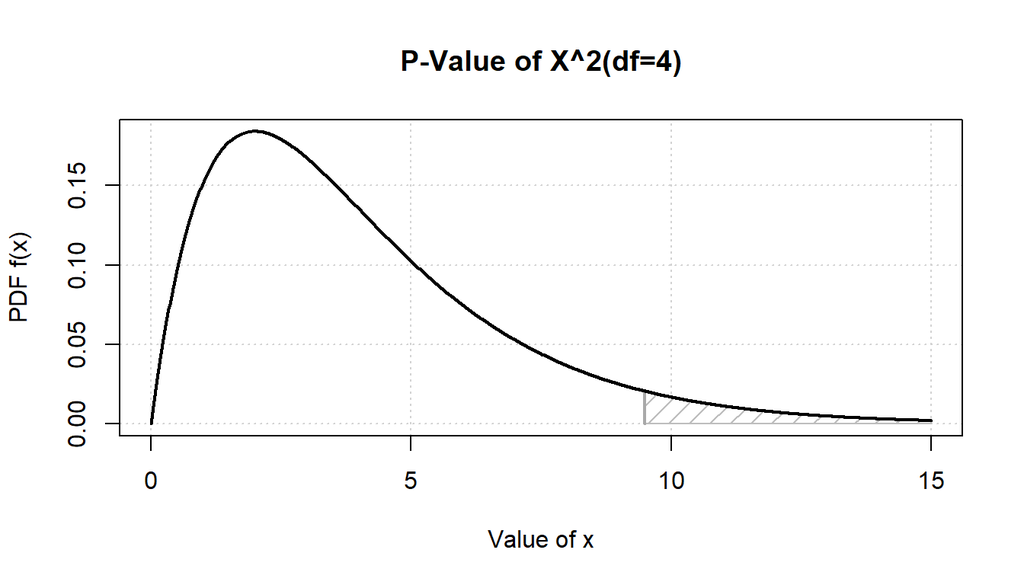

```r
# Compute right-tail p-value
pchisq(deviance(model), df = df.residual(model), lower.tail = FALSE) # Large p-value so cannot reject H0
```

```
[1] 0.9413553
```

- Rule-of-thumb: Recall that if a random variable $X\sim\mathcal{X}^2_{\text{df }=\,k}$, then $\mathbb{E}(X) = k$. Therefore, if
  $$D_\text{residual}\gg \text{df} = k -
  p$$
  then the resulting p-value should be very small so we would likely reject $H_0$.
- For linear regression, the various concepts of sum-of-squares and residual deviance are exactly the same.
  $$D_\text{residual} = SS_\text{model} =
  SS_\text{error} = \sum_{i=1}^n (y_i - \hat{y}_i)^2$$

```r
# Create some data
n <- 10
x <- rnorm(n)
y <- 1 + 2 * x + rnorm(n, sd=0.5)

# Fit linear regression model
model <- lm(y ~ x)

# Residual deviance
deviance(model)
sum(residuals(model) ^ 2) # SS_error = SS_model
```

```
[1] 1.221191
[1] 1.221191
```

- So far our focus is on grouped data. For ungrouped data, many of the statistical techniques above are invalid. For example:
  - Each group only has $n_i = 1$ data point. For the saturated model, the perfect predicted probability is simply the observed response $y_i$ itself i.e.
    $$p_i^\text{saturated} = y_i
    \quad\text{for } i =1,\dotsc,n$$
  - Log-likelihood value of the saturated model becomes
    $$l_\text{saturated} = \sum_{i=1}^n
    y_i\log(\underbrace{p_i^\text{saturated}}_{y_i}) + (1 - y_i)
    \log(\underbrace{1 - p_i^\text{saturated}}_{1-y_i}) = 0$$
    Consequently, the residual deviance $D_\text{residual}$ value is different from the grouped data version.
  - Residual degrees of freedom becomes $n - p$. It is much larger than $k - p$ before.
  - Most importantly, the residual deviance $D_\text{residual}$ does not have an approximate $\mathcal{X}^2$ (or any other known) reference probability distribution under the null hypothesis $H_0$ anymore, no matter how large the number $n$ of data points is.
    $$D_\text{residual}\overset{d}{\not\approx}\mathcal{X}^2_{\text{df
    }=\,?}\quad\text{under } H_0$$
    So residual deviance $D_\text{residual}$ cannot be used to assess goodness-of-fit of the model anymore.

```r
# Model of interest
model <- glm(tidy ~ star, family = binomial, data = hotel) # Ungrouped data

summary(model)
```

```
Call:
glm(formula = tidy ~ star, family = binomial, data = hotel)

Coefficients:
            Estimate Std. Error z value Pr(>|z|)
(Intercept)  -2.1976     0.8052  -2.729  0.00635 **
star          0.8024     0.2556   3.139  0.00170 **
---
Signif. codes:  0 '***' 0.001 '**' 0.01 '*' 0.05 '.' 0.1 ' ' 1

(Dispersion parameter for binomial family taken to be 1)

    Null deviance: 68.994  on 49  degrees of freedom
Residual deviance: 56.445  on 48  degrees of freedom
AIC: 60.445

Number of Fisher Scoring iterations: 4
```

```r
# Log-likelihood of model
logLik(model)

y <- hotel$tidy
p.model <- fitted(model) # Usual predicted probability p_i
(l.model <- sum(y * log(p.model) + (1 - y) * log(1 - p.model))) # Bernoulli not binomial
```

```
'log Lik.' -28.22239 (df=2)
[1] -28.22239
```

```r
# Log-likelihood of saturated model
l.saturated <- 0

# Residual deviance
deviance(model)
-2 * (l.model - l.saturated)
```

```
[1] 56.44477
[1] 56.44477
```

```r
# Residual degrees of freedom
model$df.residual

n <- length(y) # Total number of data points
p <- 2 # Number of parameters
n - p
```

```
[1] 48
[1] 48
```

- In practice, how can we assess goodness-of-fit of a model for ungrouped data?
  - In statistics literature, some people are inspired by the coefficient of determination $R^2$ of linear regression and consider the ratio
    $$1
    - \frac{D_\text{residual}}{D_\text{null}} = 1 -
    \frac{l_\text{model}}{l_\text{null}} \in[0,1]$$
    as the “percentage / proportion of deviance explained”. Note this is not the same as “percentage / proportion of variation in the response variable that is explained by the explanatory variables of the model” or the correlation between the observed response and predicted probability.
  - In machine learning, people tend to focus on predictive performance and error i.e. residual. If many data points have large residuals, then this would indicate a lack of fit. Moreover, if we choose a threshold $\tau\in(0,1)$ for the predicted probability, then we can compute a confusion matrix and related metrics e.g. accuracy / precision / recall. These are easier to interpret on an absolute scale and are likely to have direct business interest.

## 6.10 Model Selection with Wald Test and Likelihood Ratio Test

- Previously for linear regression, we have Wald $t$-test and F-test to compare a larger model vs a smaller nested model for the purpose of model selection. These two statistical hypothesis tests are equivalent. Moreover, their reference probability distributions (for computing p-value) are exact.
- Now for logistic regression, we have **Wald $z$-test** and **$\mathcal{X}^2$ likelihood ratio test LRT**. But their reference probability distributions are only asymptotic / approximate. It is under the assumption that either each group size $n_i$ or the number of groups $k$ (for grouped data) or the number of data points $n$ (for ungrouped data) is sufficiently large.
- **Wald $z$-test**: To decide to select an explanatory variable $x_j$ or not, we consider the statistical hypothesis test
  $$H_0: \beta_j=0
  \quad\quad\text{vs}\quad\quad H_a: \beta_j\neq 0$$
  We compute $z$-statistic
  $$z_j=\frac{\hat{\beta}_j -
  0}{\text{s.e.}(\hat{\beta}_j)} \overset{d}{\approx}
  \mathcal{N}(0,1)\quad\text{under }H_0:\beta_j=0$$
  Some remarks:
  - The $\text{s.e.}(\hat{\beta}_j)$ standard error computation is more complicated than previously for linear regression. (Don’t worry about it.)
  - As the number of groups $k$ or number of data points $n\rightarrow\infty$, the Student’s $t$ distribution converges to the standard normal distribution i.e.
    $$t_{\text{df }\,=
    n-p}\overset{d}{\approx}\mathcal{N}(0,1)$$
    Moreover, the reference probability distribution is merely asymptotic / approximate. Therefore, it is okay to use the standard normal $\mathcal{N}(0,1)$ distribution here.
  - Approximation improves as the group size / number of groups (for grouped data) / number of data points (for ungrouped data) increases. In particular, Wald $z$-test is valid for ungrouped data too.
  - If the explanatory variable $x_j$ is useful, then $\hat{\beta}_j\not\approx 0$ so $|z_j|$ is large. The resulting two-sided p-value would be small. So we reject $H_0$ accordingly.
- The `Pr(>|z|)` column in R’s `summary(model)` provides a quick overview of individual hypothesis tests $H_0: \beta_j=0$ for each model parameter $\beta_j$.

```r
# Create some data
set.seed(1)

n <- 100
d <- 4
X <- matrix(rnorm(n * d), n, d)
colnames(X) <- paste0('x', 1:d)

beta <- c(1, 2, 4, 0, 0.5) # So x3 is not useful and x4 is somewhat
p <- 1 / (1 + exp(-(beta[1] + X %*% beta[-1]))) # P(Y=1)
y <- sapply(p, function(p) rbinom(1, 1, p))

data <- as.data.frame(cbind(y, X))

head(data)
```

```
  y         x1          x2         x3         x4
1 0 -0.6264538 -0.62036668  0.4094018  0.8936737
2 1  0.1836433  0.04211587  1.6888733 -1.0472981
3 1 -0.8356286 -0.91092165  1.5865884  1.9713374
4 1  1.5952808  0.15802877 -0.3309078 -0.3836321
5 0  0.3295078 -0.65458464 -2.2852355  1.6541453
6 1 -0.8204684  1.76728727  2.4976616  1.5122127
```

```r
# Wald z-test
model <- glm(y ~ x1 + x2 + x3 + x4, family = binomial, data = data)

summary(model)
```

```
Call:
glm(formula = y ~ x1 + x2 + x3 + x4, family = binomial, data = data)

Coefficients:
            Estimate Std. Error z value Pr(>|z|)
(Intercept)   0.5568     0.4315   1.290 0.196911
x1            2.3817     0.6238   3.818 0.000135 ***
x2            4.5772     1.1632   3.935 8.32e-05 ***
x3            0.3147     0.3652   0.862 0.388886
x4            0.9580     0.5423   1.766 0.077317 .
---
Signif. codes:  0 '***' 0.001 '**' 0.01 '*' 0.05 '.' 0.1 ' ' 1

(Dispersion parameter for binomial family taken to be 1)

    Null deviance: 137.989  on 99  degrees of freedom
Residual deviance:  49.244  on 95  degrees of freedom
AIC: 59.244

Number of Fisher Scoring iterations: 7
```

```r
# Step 1: Compute standard error for beta
C <- summary(model)$cov.scaled # Cov(estimated beta)  Same as $cov.unscaled and vcov(model)
(s.e.beta <- sqrt(diag(C))) # s.e.(beta)
```

```
(Intercept)          x1          x2          x3          x4
  0.4314875   0.6237904   1.1631953   0.3652394   0.5423289
```

```r
# Step 2: Compute z-statistic
beta <- coef(model)
(z.stat <- beta / s.e.beta)
```

```
(Intercept)          x1          x2          x3          x4
  1.2904030   3.8180437   3.9350125   0.8616392   1.7664684
```

```r
# Step 3: Compute (two-sided) p-value using reference N(0,1) distribution
(p.value <- 2 * pnorm(abs(z.stat), lower.tail = FALSE))
```

```
 (Intercept)           x1           x2           x3           x4
1.969108e-01 1.345141e-04 8.319235e-05 3.888861e-01 7.731730e-02
```

- Similar to linear regression, here the interpretation of a Wald test’s p-value is “this explanatory variable is the last to be included into the model when all other explanatory variables are already present”. Therefore, if we remove one explanatory variable from the model, then the p-values of the other remaining explanatory variables will change with respect to the reduced model. Moreover, we still need to be careful about the issue of multicollinearity and misleading inflated p-value.
- In general, to compare a larger model vs a smaller nested model, we will reformulate the previous $\mathcal{X}^2$ goodness-of-fit test with residual deviance $D_\text{residual}$ in such a way that generalizes naturally to the **$\mathcal{X}^2$ likelihood ratio test LRT** for the purpose of nested model selection.
- Let’s rewrite
  $$D_\text{residual} = -2
  \left(l_\text{model} - l_\text{saturated}\right) = -2\left(\log
  L_\text{model} - \log L_\text{saturated}\right) = -2
  \log\underbrace{\left(\frac{L_\text{model}}{L_\text{saturated}}\right)}_\text{likelihood
  ratio} > 0$$
  For the $\mathcal{X}^2$ goodness-of-fit test, under the null hypothesis $H_0$ that the model of interest fits the observed data points adequately i.e. almost as good as the saturated model, this log likelihood ratio test statistic would have the reference probability distribution
  $$D_\text{residual} = -2
  \log\left(\frac{L_\text{model}}{L_\text{saturated}}\right)
  \overset{d}{\approx} \mathcal{X}^2_{\text{df }=\,k\,-\,p \,=\,p^\text{
  saturated} \,-\,p^\text{ model}}\quad\text{under }H_0$$
  This motivates us to consider statistical hypothesis testing using log likelihood ratio.
- Suppose we have a smaller model nested within a larger model. As a model includes more explanatory variables and becomes more complex, its residual deviance $D_\text{residual}$ always decreases. Therefore, we have
  $$D_\text{residual}^\text{ small} >
  D_\text{residual}^\text{ large}$$
  along with the numbers of model parameters
  $$p^\text{ small} < p^\text{
  large}$$
  The difference in residual deviances is
  $$D_\text{residual}^\text{ small} -
  D_\text{residual}^\text{ large} = -2 \left(l_\text{model}^\text{ small}
  - l_\text{saturated}\right) + 2 \big(l_\text{model}^\text{ large} -
  l_\text{saturated}\big) = -2
  \log\underbrace{\left(\frac{L_\text{small}}{L_\text{large}}\right)}_\text{likelihood
  ratio} > 0$$
- **$\mathcal{X}^2$ likelihood ratio test LRT:** Let’s consider the statistical hypothesis test
  $$H_0: \text{smaller model
  fits adequately}\quad\quad\text{vs}\quad\quad H_a: \text{smaller model
  fits worse}$$
  Suppose either each group size $n_i$ or the number of groups $k$ (for grouped data) or the number of data points $n$ (for ungrouped data) is sufficiently large. Under the null hypothesis $H_0$ that the smaller model fits as good as the larger model, we have the asymptotic / approximate
  $$D_\text{residual}^\text{ small} -
  D_\text{residual}^\text{ large} = -2
  \log\left(\frac{L_\text{small}}{L_\text{large}}\right)
  \overset{d}{\approx} \mathcal{X}^2_{\text{df }=\,p^\text{
  large}\,-\,p^\text{ small}}\quad\text{under }H_0$$
  This reference probability distribution provides a benchmark to decide if the decrease $D_\text{residual}^\text{ small} - D_\text{residual}^\text{ large}$ is large enough to worth the increase in the number of explanatory variables $p^\text{ large} - p^\text{ small}$. This is also called **analysis of deviance**.
- This $\mathcal{X}^2$ likelihood ratio test is valid for ungrouped data too. But this does not imply nor require each individual $D_\text{residual}^\text{ small}$ or $D_\text{residual}^\text{ large}$ to have approximate $\mathcal{X}^2$ distribution.
- R’s `anova(..., ..., test = 'Chisq')` performs the $\mathcal{X}^2$ likelihood ratio test LRT.

```r
large.model <- glm(y ~ x1 + x2 + x3 + x4, family = binomial, data = data)
(D.large <- deviance(large.model))
(p.large <- 5) # Same as large.model$rank
```

```
[1] 49.24394
[1] 5
```

```r
small.model <- update(large.model, ~ . - x3 - x4) # H0: b3 = b4 = 0

summary(small.model)
```

```
Call:
glm(formula = y ~ x1 + x2, family = binomial, data = data)

Coefficients:
            Estimate Std. Error z value Pr(>|z|)
(Intercept)   0.5858     0.4149   1.412    0.158
x1            2.2177     0.5625   3.943 8.06e-05 ***
x2            3.8268     0.8949   4.276 1.90e-05 ***
---
Signif. codes:  0 '***' 0.001 '**' 0.01 '*' 0.05 '.' 0.1 ' ' 1

(Dispersion parameter for binomial family taken to be 1)

    Null deviance: 137.989  on 99  degrees of freedom
Residual deviance:  53.327  on 97  degrees of freedom
AIC: 59.327

Number of Fisher Scoring iterations: 7
```

```r
(D.small <- deviance(small.model))
(p.small <- 3) # Same as small.model$rank
```

```
[1] 53.3271
[1] 3
```

```r
# Based on X^2 likelihood ratio test LRT by default instead of F-test
anova(small.model, large.model) # Same as anova(..., test = 'Chisq') and anova(..., test = 'LRT')
```

```
Analysis of Deviance Table

Model 1: y ~ x1 + x2
Model 2: y ~ x1 + x2 + x3 + x4
  Resid. Df Resid. Dev Df Deviance Pr(>Chi)
1        97     53.327
2        95     49.244  2   4.0832   0.1298
```

```r
# Compute X^2-statistic and p-value manually
(diff.D <- D.small - D.large)
(diff.p <- p.large - p.small)

(p.value <- pchisq(diff.D, df = diff.p, lower.tail=FALSE)) # Not small p-value so cannot reject H0
```

```
[1] 4.083156
[1] 2
[1] 0.1298237
```

- R’s `anova(..., test = 'Chisq')` can perform sequential $\mathcal{X}^2$ likelihood ratio test LRT too.
  - It starts with the (smallest) null model with only the intercept term `glm(y ~ 1, ...)`.
  - Each additional explanatory variable is included into the model in the order they appear the R’s model formula `y ~ x1 + x2 + ...`.
  - The reported p-value `Pr(>Chi)` is based on the $\mathcal{X}^2$ likelihood ratio test LRT this additional explanatory variable when all previously added explanatory variables are already present in the model.

```r
anova(large.model) # Same as anova(..., test = 'Chisq') and anova(..., test = 'LRT')
```

```
Analysis of Deviance Table

Model: binomial, link: logit

Response: y

Terms added sequentially (first to last)

     Df Deviance Resid. Df Resid. Dev  Pr(>Chi)
NULL                    99    137.989
x1    1   17.147        98    120.842  3.46e-05 ***
x2    1   67.515        97     53.327 < 2.2e-16 ***
x3    1    0.254        96     53.074   0.61457
x4    1    3.830        95     49.244   0.05036 .
---
Signif. codes:  0 '***' 0.001 '**' 0.01 '*' 0.05 '.' 0.1 ' ' 1
```

- To perform forward / backward / stepwise regression, R’s `add1(..., test = 'Chisq')` and `drop1(..., test = 'Chisq')` functions would report p-value based on $\mathcal{X}^2$ likelihood ratio test LRT. However, the stepwise regression `step()` variable selection logic is always based on Akaike Information Criterion AIC (when `k = 2`) or Bayes Information Criterion BIC (when `k = log(n)`) metric instead.

```r
# One iteration of backward elimination
drop1(large.model) # Do not report p-value of X^2 likelihood ratio test LRT
```

```
Single term deletions

Model:
y ~ x1 + x2 + x3 + x4
       Df Deviance     AIC
<none>      49.244  59.244
x1      1   78.647  86.647
x2      1  120.311 128.311
x3      1   50.001  58.001
x4      1   53.074  61.074
```

```r
drop1(large.model, test = 'Chisq') # Same as drop1(..., test = 'LRT')
```

```
Single term deletions

Model:
y ~ x1 + x2 + x3 + x4
       Df Deviance     AIC    LRT  Pr(>Chi)
<none>      49.244  59.244
x1      1   78.647  86.647 29.403 5.879e-08 ***
x2      1  120.311 128.311 71.068 < 2.2e-16 ***
x3      1   50.001  58.001  0.757   0.38421
x4      1   53.074  61.074  3.830   0.05036 .
---
Signif. codes:  0 '***' 0.001 '**' 0.01 '*' 0.05 '.' 0.1 ' ' 1
```

```r
# Backward elimination
step(large.model, direction = 'backward', k = 2, test = 'Chisq') # Use k = log(n) for BIC  Same as step(..., test = 'LRT')
```

```
Start:  AIC=59.24
y ~ x1 + x2 + x3 + x4

       Df Deviance     AIC    LRT  Pr(>Chi)
- x3    1   50.001  58.001  0.757   0.38421
<none>      49.244  59.244
- x4    1   53.074  61.074  3.830   0.05036 .
- x1    1   78.647  86.647 29.403 5.879e-08 ***
- x2    1  120.311 128.311 71.068 < 2.2e-16 ***
---
Signif. codes:  0 '***' 0.001 '**' 0.01 '*' 0.05 '.' 0.1 ' ' 1

Step:  AIC=58
y ~ x1 + x2 + x4

       Df Deviance     AIC    LRT  Pr(>Chi)
<none>      50.001  58.001
- x4    1   53.327  59.327  3.326   0.06819 .
- x1    1   78.935  84.935 28.934 7.489e-08 ***
- x2    1  120.342 126.342 70.341 < 2.2e-16 ***
---
Signif. codes:  0 '***' 0.001 '**' 0.01 '*' 0.05 '.' 0.1 ' ' 1

Call:  glm(formula = y ~ x1 + x2 + x4, family = binomial, data = data)

Coefficients:
(Intercept)           x1           x2           x4
     0.5340       2.3117       4.3107       0.8401

Degrees of Freedom: 99 Total (i.e. Null);  96 Residual
Null Deviance:      138
Residual Deviance: 50   AIC: 58
```

- In logistic regression, for the null hypothesis $H_0: \beta_j = 0$ to decide to select the explanatory variable $x_j$ or not, are the Wald $z$-test vs $\mathcal{X}^2$ likelihood ratio test LRT equivalent (like the Wald $t$-test vs F-test for linear regression)? No. They yield different p-values.

```r
summary(large.model) # Wald z-test
```

```
Call:
glm(formula = y ~ x1 + x2 + x3 + x4, family = binomial, data = data)

Coefficients:
            Estimate Std. Error z value Pr(>|z|)
(Intercept)   0.5568     0.4315   1.290 0.196911
x1            2.3817     0.6238   3.818 0.000135 ***
x2            4.5772     1.1632   3.935 8.32e-05 ***
x3            0.3147     0.3652   0.862 0.388886
x4            0.9580     0.5423   1.766 0.077317 .
---
Signif. codes:  0 '***' 0.001 '**' 0.01 '*' 0.05 '.' 0.1 ' ' 1

(Dispersion parameter for binomial family taken to be 1)

    Null deviance: 137.989  on 99  degrees of freedom
Residual deviance:  49.244  on 95  degrees of freedom
AIC: 59.244

Number of Fisher Scoring iterations: 7
```

```r
drop1(large.model, test = 'Chisq') # X^2 likelihood ratio test LRT
```

```
Single term deletions

Model:
y ~ x1 + x2 + x3 + x4
       Df Deviance     AIC    LRT  Pr(>Chi)
<none>      49.244  59.244
x1      1   78.647  86.647 29.403 5.879e-08 ***
x2      1  120.311 128.311 71.068 < 2.2e-16 ***
x3      1   50.001  58.001  0.757   0.38421
x4      1   53.074  61.074  3.830   0.05036 .
---
Signif. codes:  0 '***' 0.001 '**' 0.01 '*' 0.05 '.' 0.1 ' ' 1
```

- Which one between the Wald $z$-test vs $\mathcal{X}^2$ likelihood ratio test LRT should we use?
  - Since the larger vs smaller models only differ by one explanatory variable $x_j$, the difference in their numbers of parameters is $p^\text{large} - p^\text{small} = 1$. The two hypothesis tests actually have the same asymptotic reference probability distribution (up to squaring)
    $$\mathcal{N}(0,1)^2 \overset{d}{=}
    \mathcal{X}^2_{\text{df }\,=1}$$
  - Different p-values are due to different test statistic values i.e.
    $$z_j =
    \frac{\hat{\beta}_j}{\text{s.e.}(\hat{\beta}_j)} \quad\text{vs}\quad
    D_\text{residual}^\text{ small} - D_\text{residual}^\text{
    large}$$
  - In practice, $\mathcal{X}^2$ likelihood ratio test LRT is usually more accurate / reliable and hence preferred over the Wald $z$-test.
- For linear regression, we know the Wald $t$-test vs F-test are equivalent. If we view linear regression as a generalized linear model GLM, then can we also use the asymptotic / approximate $\mathcal{X}^2$ likelihood ratio test LRT for nested model selection too instead of the F-test? In theory, they are related. As the number of data points $n\rightarrow\infty$ increases, (a scaled version of) the $\mathcal{X}^2$ distribution converges to the F-distribution.
  $$\frac{1}{p^\text{large} - p^\text{small}}
  \mathcal{X}^2_{\text{df } =\,p^\text{large}\,-\,p^\text{small}}
  \overset{d}{\approx} F_{(p^\text{large} - p^\text{small}),\,(n -
  p^\text{large})}$$
  However, in practice we should always use the exact F-test for linear regression.
- Since $\mathcal{X}^2$ likelihood ratio test LRT is only applicable to nested model selection, in order to compare two non-nested models, we should use Akaike Information Criterion AIC or Bayes Information Criterion BIC instead (similar to the approach for linear regression).

```r
# Compute AIC
AIC(model)
model$aic
-2 * logLik(model) + 2 * p.large
```

```
[1] 59.24394
[1] 59.24394
'log Lik.' 59.24394 (df=5)
```

- Now we understand all the numbers reported in R’s `summary()` for logistic regression model.

```r
summary(model)
```

```
Call:
glm(formula = y ~ x1 + x2 + x3 + x4, family = binomial, data = data)

Coefficients:
            Estimate Std. Error z value Pr(>|z|)
(Intercept)   0.5568     0.4315   1.290 0.196911
x1            2.3817     0.6238   3.818 0.000135 ***
x2            4.5772     1.1632   3.935 8.32e-05 ***
x3            0.3147     0.3652   0.862 0.388886
x4            0.9580     0.5423   1.766 0.077317 .
---
Signif. codes:  0 '***' 0.001 '**' 0.01 '*' 0.05 '.' 0.1 ' ' 1

(Dispersion parameter for binomial family taken to be 1)

    Null deviance: 137.989  on 99  degrees of freedom
Residual deviance:  49.244  on 95  degrees of freedom
AIC: 59.244

Number of Fisher Scoring iterations: 7
```

# 7 Poisson Regression

## 7.1 Poisson${\small(\lambda)}$

- A random variable $X \sim ~ \text{Poisson}(\lambda)$ with **rate** or **intensity** parameter $\lambda > 0$ takes on value in the non-negative integers $\{0,1,2,\dotsc\}$.

```r
# Simulate Poisson(4) observations
lambda <- 4
rpois(20, lambda = lambda)
```

```
 [1] 6 5 3 2 2 1 1 2 1 1 4 6 5 1 0 4 2 5 5 6
```

- Probability mass function $p_X$ is
  $$P(X=x) = p_X(x) =
  e^{-\lambda}\frac{\lambda^x}{x!}\quad\text{for } x=0,1,2,\dotsc$$
  where $e=2.71828\dotso$ is the Euler’s number for [natural logarithm](https://en.wikipedia.org/wiki/Natural_logarithm). The [power series](https://en.wikipedia.org/wiki/Power_series)
  $$1 + \lambda + \frac{\lambda^2}{2!} +
  \frac{\lambda^3}{3!} +\dotsb = \sum_{x=1}^\infty \frac{\lambda^x}{x!} =
  e^{\lambda}$$
  sums up accordingly.
- Mean $\mathbb{E}(X)$ and variance $\text{Var}(X)$ are the same i.e.
  $$\mathbb{E}(X) =
  \text{Var}(X)=\lambda$$
- Probability mass function $p_X$ is unimodal, centered near its mean $E(X)=\lambda$, and right-skewed.

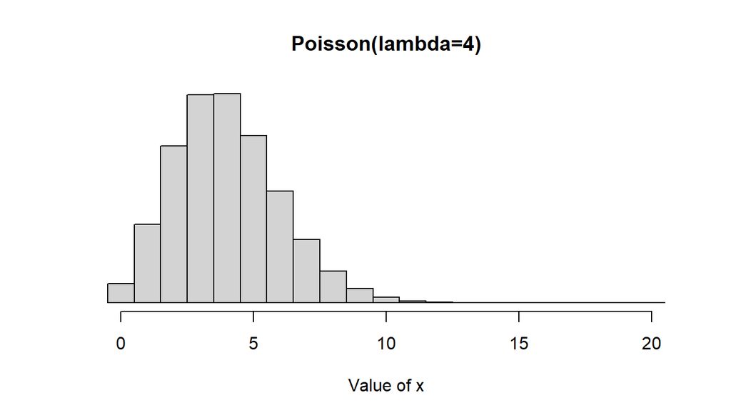

- In practice, it is often used in a [generalized linear model](https://en.wikipedia.org/wiki/Generalized_linear_model) GLM called [Poisson regression](https://en.wikipedia.org/wiki/Poisson_regression) to count the number of occurrences of a large number of possible random events, each of which is rare. For example, the number of pedestrians in a city involved in traffic accidents in a year.
- [**Poisson limit theorem**](https://en.wikipedia.org/wiki/Poisson_limit_theorem) / [law of rare events](https://en.wikipedia.org/wiki/Poisson_distribution#Law_of_rare_events): If $n$ is large and $p\approx 0$ is small, then
  $$\text{Binom}(n, p)
  \overset{d}{\approx}\text{Poisson}(\lambda=np)$$
  In other words, in this case, we could simplify our modeling and computation by approximating the exact binomial distribution with a related Poisson distribution.

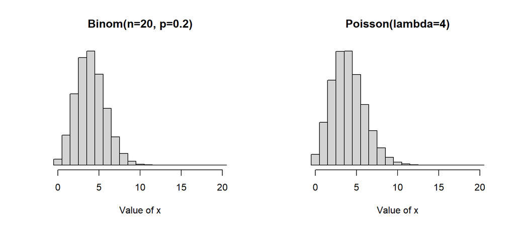

## 7.2 Count Data

- [**Poisson regression**](https://en.wikipedia.org/wiki/Poisson_regression) is a kind of generalized linear model GLM for count data i.e. the response variable $Y\in\{0, 1, 2, \dotsc,\}$ takes non-negative integer value only.
- *Example:* Let $Y$ be the number of cars in a city that had an accident in a year.
  - Strictly speaking, if we assume there are only $n$ number of cars in the city, then $Y \leq n$ is bounded above. So it is not exactly a Poisson distribution (whose value is unbounded).
  - Moreover, if we assume each car has an independent probability $p\in(0,1)$ to be involved in an accident, then $Y$ follows a $\text{Binom}(n,p)$ binomial distribution. So it should be modeled using logistic regression instead.
  - Nonetheless, if $n\gg 1$ is large and $p\approx 0$ is small, then the Poisson limit theorem says
    $$Y \sim
    \text{Binom}(n,p)\overset{d}{\approx}\text{Poisson}(\lambda=np)$$
    is approximately Poisson distributed. Therefore, Poisson regression model is sometime used as an approximation for simplicity.
- *Example:* Let $Y$ be the number of customers that arrive at a restaurant within a fixed period of time e.g. an hour or a day. Let $x$ be the amount of promotion discount during that period of time.
  - In statistics literature, such an [arrival process](https://en.wikipedia.org/wiki/Markovian_arrival_process) might be modeled as a [Poisson point process](https://en.wikipedia.org/wiki/Poisson_process) with [exponentially distributed](https://en.wikipedia.org/wiki/Exponential_distribution) (random) inter-arrival time. In this case, the number of arrivals itself follows a Poisson distribution.

```r
promo <- c(0.02, 0.09, 0.11, 0.13, 0.15, 0.16, 0.19, 0.22, 0.23, 0.25,
           0.25, 0.27, 0.27, 0.28, 0.28, 0.29, 0.30, 0.30, 0.31, 0.32,
           0.36, 0.37, 0.40, 0.41, 0.42, 0.43, 0.43, 0.44, 0.45, 0.46,
           0.47, 0.47, 0.48, 0.48, 0.48, 0.49, 0.52, 0.52, 0.54, 0.56,
           0.57, 0.59, 0.60, 0.63, 0.64, 0.68, 0.75, 0.78, 0.80, 0.83)
customer <- c(19, 17, 23, 24, 20, 19, 20, 32, 31, 25,
              23, 28, 26, 25, 31, 32, 33, 30, 24, 31,
              23, 44, 37, 41, 27, 50, 40, 35, 40, 45,
              40, 35, 45, 41, 34, 41, 46, 39, 48, 50,
              56, 39, 43, 50, 34, 58, 70, 72, 54, 82)
```

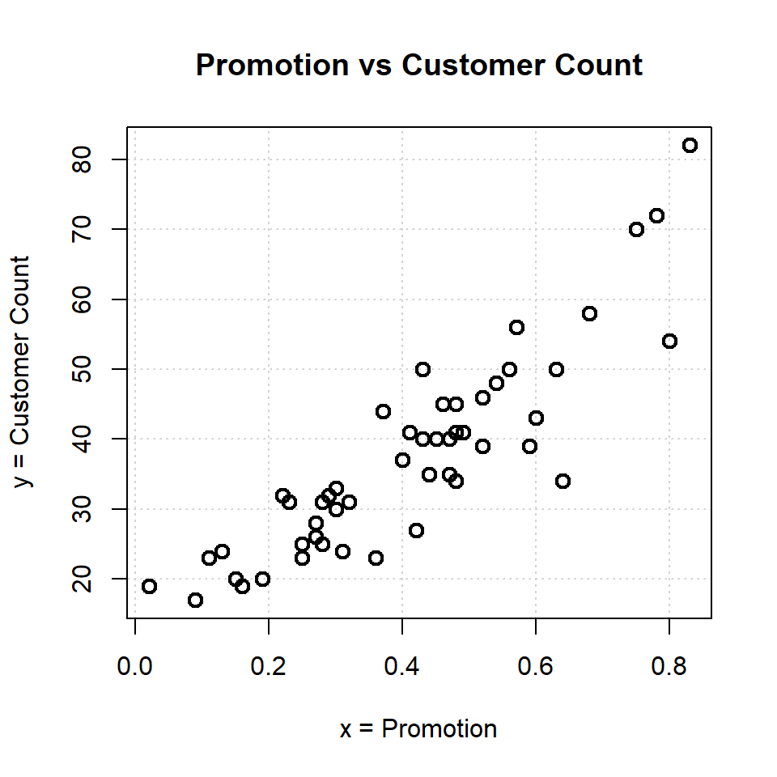

- Sometimes we view a large number $n$ of occurrences of events as approximately normally distributed too. This is based on the [central limit theorem CLT](https://en.wikipedia.org/wiki/Central_limit_theorem).
  $$Y \sim \text{Binom}(n,p)
  \overset{d}{\approx} \mathcal{N}(\mu = np, \sigma^2 =
  np(1-p))\quad\text{for large }n\gg1$$
- In practice, a data set could be viewed in multiple ways and modeled accordingly e.g. using linear regression / logistic regression / Poisson regression.

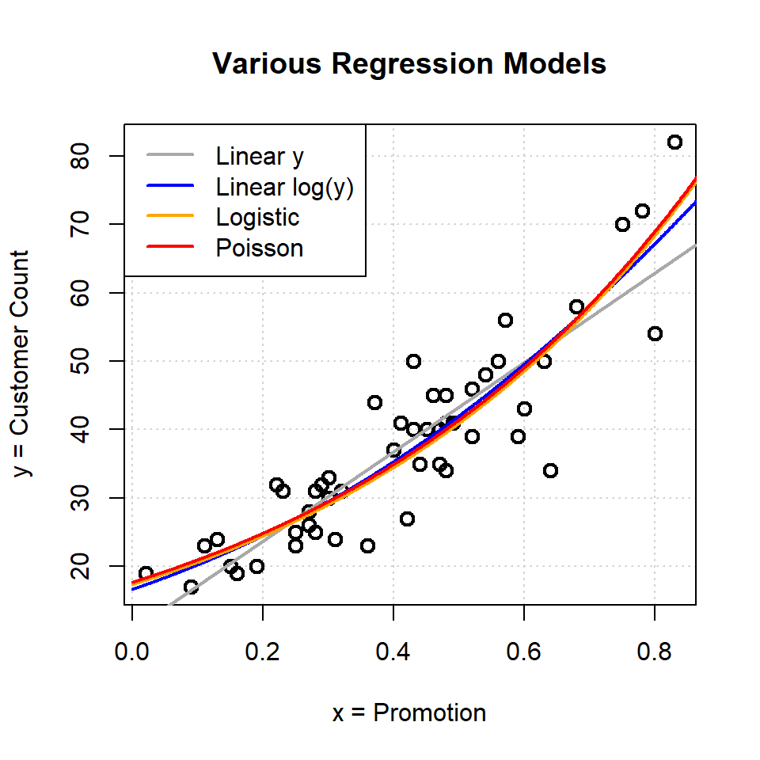

```r
# Model 1: Linear regression with y
model.1 <- lm(customer ~ promo)

summary(model.1)
```

```
Call:
lm(formula = customer ~ promo)

Residuals:
     Min       1Q   Median       3Q      Max
-18.5004  -3.7695  -0.1934   3.3779  17.0908

Coefficients:
            Estimate Std. Error t value Pr(>|t|)
(Intercept)   10.702      2.239   4.779  1.7e-05 ***
promo         65.310      4.962  13.162  < 2e-16 ***
---
Signif. codes:  0 '***' 0.001 '**' 0.01 '*' 0.05 '.' 0.1 ' ' 1

Residual standard error: 6.661 on 48 degrees of freedom
Multiple R-squared:  0.783, Adjusted R-squared:  0.7785
F-statistic: 173.2 on 1 and 48 DF,  p-value: < 2.2e-16
```

```r
# Model 2: Linear regression with log(y)
model.2 <- lm(log(customer) ~ promo)

summary(model.2)
```

```
Call:
lm(formula = log(customer) ~ promo)

Residuals:
     Min       1Q   Median       3Q      Max
-0.42573 -0.11639  0.03381  0.09984  0.31989

Coefficients:
            Estimate Std. Error t value Pr(>|t|)
(Intercept)  2.85509    0.05438   52.50   <2e-16 ***
promo        1.71406    0.12051   14.22   <2e-16 ***
---
Signif. codes:  0 '***' 0.001 '**' 0.01 '*' 0.05 '.' 0.1 ' ' 1

Residual standard error: 0.1618 on 48 degrees of freedom
Multiple R-squared:  0.8082,    Adjusted R-squared:  0.8042
F-statistic: 202.3 on 1 and 48 DF,  p-value: < 2.2e-16
```

```r
# Model 3: Logistic regression with group size assumption
total.ppl <- 200 # Group size n_i
k <- length(promo) # Number of groups k
model.3 <- glm(customer / total.ppl ~ promo, family = binomial, weights = rep(total.ppl, k))

summary(model.3)
pchisq(deviance(model.3), df.residual(model.3), lower.tail = FALSE) # P-value of X^2 goodness-of-fit test
```

```
Call:
glm(formula = customer/total.ppl ~ promo, family = binomial,
    weights = rep(total.ppl, k))

Coefficients:
            Estimate Std. Error z value Pr(>|z|)
(Intercept) -2.39786    0.06764  -35.45   <2e-16 ***
promo        2.14573    0.13690   15.67   <2e-16 ***
---
Signif. codes:  0 '***' 0.001 '**' 0.01 '*' 0.05 '.' 0.1 ' ' 1

(Dispersion parameter for binomial family taken to be 1)

    Null deviance: 309.634  on 49  degrees of freedom
Residual deviance:  58.246  on 48  degrees of freedom
AIC: 321.68

Number of Fisher Scoring iterations: 4

[1] 0.1476883
```

```r
# Model 4: Poisson regression
model.4 <- glm(customer ~ promo, family = poisson)

summary(model.4)
pchisq(deviance(model.4), df.residual(model.4), lower.tail = FALSE) # P-value of X^2 goodness-of-fit test
```

```
Call:
glm(formula = customer ~ promo, family = poisson)

Coefficients:
            Estimate Std. Error z value Pr(>|z|)
(Intercept)  2.87376    0.06087   47.21   <2e-16 ***
promo        1.69984    0.11923   14.26   <2e-16 ***
---
Signif. codes:  0 '***' 0.001 '**' 0.01 '*' 0.05 '.' 0.1 ' ' 1

(Dispersion parameter for poisson family taken to be 1)

    Null deviance: 247.151  on 49  degrees of freedom
Residual deviance:  45.697  on 48  degrees of freedom
AIC: 319.69

Number of Fisher Scoring iterations: 4

[1] 0.5676976
```

## 7.3 Log Link Function

- Let $(\vec{x}_1,y_1),\dotsc,(\vec{x}_n,y_n)$ be $n$ pairs of observed data points with $d$-dimensional explanatory variable $\vec{x}_i = (x_{i1},\dotsc,x_{id})\in\mathbb{R}^d$ and count response variable $y_i\in\{0,1,2,\dotsc\}$.
- The statistical model assumption of Poisson regression is:
  1. **Deterministic explanatory variable:** Explanatory variables $\vec{x}_i$ is fixed / deterministic / not a random variable in this statistical model.
  2. **Random response variable:** Response variable $Y_i$ is viewed as a random variable. Each observed response value $y_i$ is a realization of its random variable $Y_i$.
  3. **Independence:** The response variables $Y_i$’s are independent random variables. (In this case, the likelihood function factors into a product of $n$ terms for easier mathematical computation later.)
  4. **Poisson distributed:** Since each random variable $Y_i\in\{0,1,2,\dotsc\}$ is a non-negative integer, we assume a Poisson distribution
     $$Y_i\sim\text{Poisson}(\lambda_i)$$
     For each $i^\text{th}$ observed data point, the Poisson intensity parameter $\lambda_i > 0$ can be different.
  5. **Linear:** There is an increasing relationship between the expected count $\lambda_i = \mathbb{E}(Y_i)$ and linear combination of explanatory variable $\vec{x}_i$.
     $$\underbrace{\mathbb{E}(Y_i)}_{\lambda_i}
     \quad\text{vs}\quad \underbrace{\beta_0 + \beta_1 x_{i1} + \dotsb +
     \beta_d x_{id}}_\text{linear combination}$$
     If the right-hand side increases, then the left-hand side should increase too, and vice versa. Here the $\beta_0,\dotsc,\beta_d$ parameters are common across all $n$ data points. They are unknown and are to be estimated from the data.
  6. **Log as link function:** There is some monotonic increasing function $f:\mathbb{R}\mapsto (0,\infty)$ that links the right-hand side and left-hand side together.
     $$\underbrace{\mathbb{E}(Y_i)}_{\lambda_i} =
     f(\beta_0 + \beta_1 x_{i1} + \dotsb + \beta_d x_{id})$$
     For each $i^\text{th}$ observed data point, since $\vec{x}_i$ can be different, so could $\lambda_i$. There is actually a natural / default / canonical choice for this function $f$ i.e. the exponential function $f(x)=e^x$. Combining the above together, the Poisson regression model equation is
     $$\mathbb{E}(Y_i)=\lambda_i = e^{\beta_0 + \beta_1
     x_{i1} + \dotsb + \beta_d x_{id}}$$
     Equivalently, it is
     $$\log\mathbb{E}(Y_i)=\log\lambda_i = \beta_0 +
     \beta_1 x_{i1} + \dotsb + \beta_d x_{id}$$
     (Technically, in statistics literature, our function $f$ is not referred to as the link function. Instead, its inverse function $f^{-1}=\log$ is the link function.)

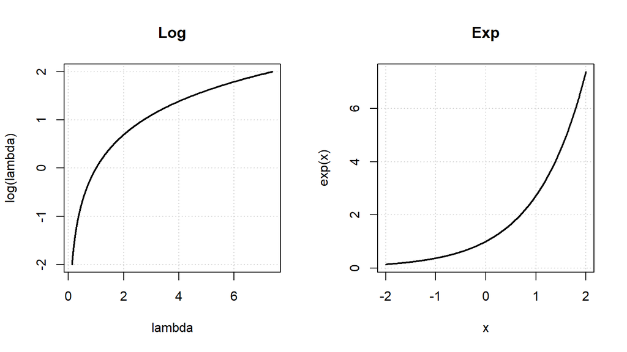

- Although the Poisson model equation above looks similar to a linear regression model when the response variable $Y_i$ is under the logarithm transformation $\log(Y_i)$ i.e. R’s `lm(log(y) ~ ...)`, these two models are different.
  - The linear regression model is
    $$\mathbb{E}(\log Y_i) = \beta_0 + \beta_1 x_{i1} +
    \dotsb + \beta_d x_{id}$$
  - By [Jensen’s inequality](https://en.wikipedia.org/wiki/Jensen%27s_inequality), we have
    $$\mathbb{E}(\log
    Y_i) < \log\mathbb{E}(Y_i)$$
    So they are not the same quantity.
  - More importantly, Poisson regression is $Y_i\sim\text{Poisson}(\lambda_i)$. But this linear regression is $\log Y_i \sim \mathcal{N}(\mu_i, \sigma^2)$ i.e. $Y_i$ itself has a [log-normal](https://en.wikipedia.org/wiki/Log-normal_distribution) distribution.
- Overall, Poisson regression with log link function is the statistical model
  $$Y_i\sim\text{Poisson}\underbrace{\left(e^{\beta_0
  + \beta_1 x_{i1} + \dotsb + \beta_d x_{id}}\right)}_{\lambda_i\, >\,
  0}\quad\text{for } i=1,\dotsc,n$$
  with parameters $\beta_0,\dotsc,\beta_d$.
- Interpretation of coefficient $\beta_j$: If $x_j$ increases by $+1$ unit to become $x_j + 1$ while all other explanatory variables do not change, then the expected count become
  $$\mathbb{E}(Y^\text{new}_i) =\lambda_i^\text{new}
  = e^{\beta_0 + \beta_1 x_{i1} + \dotsb + \beta_j(x_{ij} + 1) + \dotsb
  \beta_d x_{id}} = \lambda_i^\text{old} \times e^{\beta_j}$$
  The effect is multiplicative.
- According to properties of the Poisson distribution, we have
  $$\text{Var}(Y_i) = \mathbb{E}(Y_i) =
  \lambda_i$$
  Therefore, the variance $\text{Var}(Y_i)$ of the count response variable $Y_i$ increases naturally as the Poisson intensity parameter $\lambda_i$ / magnitude of $Y_i$ becomes larger.

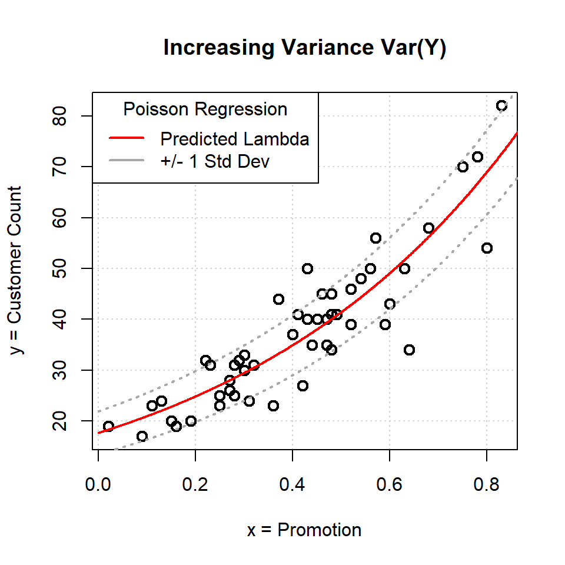

## 7.4 Model Estimation

- Given $n$ pairs of observed data points $(\vec{x}_1,y_1),\dotsc,(\vec{x}_n,y_n)$, we follow the maximum likelihood principle to estimate the $\beta_0,\dotsc,\beta_d$ parameters. Recall the likelihood function for Poisson distribution is
  $$L(\beta_0,\dotsc,\beta_d) = \prod_{i=1}^n
  P(Y_i=y_i) = \prod_{i=1}^n e^{-\lambda_i}
  \frac{\lambda_i^{y_i}}{y_i!} \quad\text{with}\quad \lambda_i =
  e^{\beta_0 + \beta_1 x_{i1} + \dotsb + \beta_d x_{id}}$$
  Therefore, $L(\beta_0,\dotsc,\beta_d)$ is indeed a function of the $\beta_0,\dotsc,\beta_d$ parameters. Now the log-likelihood function is
  $$l(\beta_0,\dotsc,\beta_d) = \log
  L(\beta_0,\dotsc,\beta_d) = \sum_{i=1}^n -\lambda_i + y_i \log\lambda_i
  - \log(y_i!)$$
  The maximum likelihood estimate MLE is
  $$\beta_0^*,\dotsc,\beta_d^* =
  \mathop{\mathrm{arg\,max}}_{\beta_0,\dotsc,\beta_d}
  l(\beta_0,\dotsc,\beta_d) =
  \mathop{\mathrm{arg\,max}}_{\beta_0,\dotsc,\beta_d} \sum_{i=1}^n
  -\lambda_i + y_i \log\lambda_i -
  \underbrace{\log(y_i!)}_\text{constant}$$
- Similarly to logistic regression, this MLE optimization problem does not have any closed-form solution. It is solved using some iterative algorithm such as [Fisher](https://en.wikipedia.org/wiki/Fisher_information) [scoring](https://en.wikipedia.org/wiki/Scoring_algorithm) algorithm.
- In R, use the `glm(..., family=poisson(...))` function to fit a Poisson regression model.

```r
promo <- c(0.02, 0.09, 0.11, 0.13, 0.15, 0.16, 0.19, 0.22, 0.23, 0.25,
           0.25, 0.27, 0.27, 0.28, 0.28, 0.29, 0.30, 0.30, 0.31, 0.32,
           0.36, 0.37, 0.40, 0.41, 0.42, 0.43, 0.43, 0.44, 0.45, 0.46,
           0.47, 0.47, 0.48, 0.48, 0.48, 0.49, 0.52, 0.52, 0.54, 0.56,
           0.57, 0.59, 0.60, 0.63, 0.64, 0.68, 0.75, 0.78, 0.80, 0.83)
customer <- c(19, 17, 23, 24, 20, 19, 20, 32, 31, 25,
              23, 28, 26, 25, 31, 32, 33, 30, 24, 31,
              23, 44, 37, 41, 27, 50, 40, 35, 40, 45,
              40, 35, 45, 41, 34, 41, 46, 39, 48, 50,
              56, 39, 43, 50, 34, 58, 70, 72, 54, 82)

model <- glm(customer ~ promo, family = poisson) # Log link is default. See ?family

# Link function
model$family$link # See str(model)

# Beta's
model
coef(model) # Same as model$coefficients and coefficients(model)
summary(model)
```

```
[1] "log"
```

```
Call:  glm(formula = customer ~ promo, family = poisson)

Coefficients:
(Intercept)        promo
      2.874        1.700

Degrees of Freedom: 49 Total (i.e. Null);  48 Residual
Null Deviance:      247.2
Residual Deviance: 45.7     AIC: 319.7
```

```
(Intercept)       promo
   2.873761    1.699845
```

```
Call:
glm(formula = customer ~ promo, family = poisson)

Coefficients:
            Estimate Std. Error z value Pr(>|z|)
(Intercept)  2.87376    0.06087   47.21   <2e-16 ***
promo        1.69984    0.11923   14.26   <2e-16 ***
---
Signif. codes:  0 '***' 0.001 '**' 0.01 '*' 0.05 '.' 0.1 ' ' 1

(Dispersion parameter for poisson family taken to be 1)

    Null deviance: 247.151  on 49  degrees of freedom
Residual deviance:  45.697  on 48  degrees of freedom
AIC: 319.69

Number of Fisher Scoring iterations: 4
```

```r
# Fitted values / predictions (for lambda_i)
fitted(model) # Same as fitted.values(model) and model$fitted.values
```

```
       1        2        3        4        5        6
18.31568 20.63001 21.34342 22.08151 22.84512 23.23677
```

```r
# Fitted linear predictor i.e. b0 + b1*x1 + ... + b_d*x_d before link function
b0 <- coef(model)[1]
b1 <- coef(model)[2]
b0 + b1 * promo

model$linear.predictors
```

```
[1] 2.907758 3.026747 3.060744 3.094740 3.128737 3.145736
       1        2        3        4        5        6
2.907758 3.026747 3.060744 3.094740 3.128737 3.145736
```

```r
# Compute fitted intensity lambda_i after log link
exp(model$linear.predictors)
```

```
       1        2        3        4        5        6
18.31568 20.63001 21.34342 22.08151 22.84512 23.23677
```

```r
# Predict linear predictor before link function
x.new <- 0.3

b0 + b1 * x.new
(u <- predict(model, newdata=data.frame(promo=x.new), type='link')) # b0 + b1*x1 + ... + b_d*x_d
```

```
(Intercept)
   3.383714
       1
3.383714
```

```r
# Predict intensity lambda after log link
exp(u) # Compute log link
predict(model, newdata=data.frame(promo=x.new), type='response') # lambda
```

```
       1
29.48006
       1
29.48006
```

## 7.5 Deviance

- For Poisson regression, the concepts of null model / saturated model / null deviance / residual deviance / degrees of freedom / $\mathcal{X}^2$ goodness-of-fit test / Wald $z$-test / $\mathcal{X}^2$ likelihood ratio test LRT are the same as logistic regression. However, some of them require different formulae to compute.
- The log-likelihood value of the null model is
  $$l_\text{null} = \sum_{i=1}^n -\bar{y} + y_i
  \log\bar{y} - \log(y_i!)$$
  with constant intensity $\lambda^\text{null}$ based on the overall mean count $\bar{y}$ i.e.
  $$\lambda^\text{null} = \bar{y} =
  \frac{1}{n}\sum_{i=1}^n y_i$$

```r
# Null model
null.model <- glm(customer ~ 1, family=poisson)

summary(null.model)
```

```
Call:
glm(formula = customer ~ 1, family = poisson)

Coefficients:
            Estimate Std. Error z value Pr(>|z|)
(Intercept)  3.62274    0.02311   156.7   <2e-16 ***
---
Signif. codes:  0 '***' 0.001 '**' 0.01 '*' 0.05 '.' 0.1 ' ' 1

(Dispersion parameter for poisson family taken to be 1)

    Null deviance: 247.15  on 49  degrees of freedom
Residual deviance: 247.15  on 49  degrees of freedom
AIC: 519.14

Number of Fisher Scoring iterations: 4
```

```r
# Predicted intensity for null model
(lambda.null <- fitted(null.model))

y <- customer
mean(y) # Overall mean
```

```
    1     2     3     4     5     6
37.44 37.44 37.44 37.44 37.44 37.44
[1] 37.44
```

```r
# Log-likelihood of null model
logLik(null.model) # Or logLik(null.model)[1]
(l.null <- sum(-lambda.null + y * log(lambda.null) - lfactorial(y))) # See ?lfactorial
```

```
'log Lik.' -258.5701 (df=1)
[1] -258.5701
```

- Let
  $$l_\text{model} = \sum_{i=1}^n
  -\hat{\lambda}_i + y_i \log\hat{\lambda}_i - \log(y_i!)$$
  be the usual log-likelihood value of the fitted model of interest. For the $i^\text{th}$ data point $y_i$, this model predicts the usual fitted intensity $\hat{\lambda}_i$.

```r
# Model of interest
model <- glm(customer ~ promo, family = poisson)

# Log-likelihood of model
logLik(model)

lambda.model <- fitted(model) # Usual predicted intensity lambda_i
(l.model <- sum(-lambda.model + y * log(lambda.model) - lfactorial(y)))
```

```
'log Lik.' -157.8429 (df=2)
[1] -157.8429
```

- Let
  $$l_\text{saturated} = \sum_{i=1}^n
  -y_i + y_i \log y_i - \log(y_i!)$$
  be the log-likelihood value of the saturated model with perfect intensity
  $$\lambda_i^\text{saturated} = y_i\quad\text{for
  }i=1,\dotsc,n$$
  based on maximum likelihood estimate MLE of Poisson distribution.

```r
# Predicted intensity for saturated model
(lambda.saturated <- y)

# Log-likelihood of saturated model
(l.saturated <- sum(-lambda.saturated + y * log(lambda.saturated) - lfactorial(y)))
```

```
[1] 19 17 23 24 20 19
[1] -134.9943
```

- These three log-likelihood values continue to satisfy the following relationship with $l_\text{saturated}$ being the upper bound of log-likelihood value over all possible models.
  $$l_\text{null} < l_\text{model} <
  l_\text{saturated} < 0$$

```r
c(l.null, l.model, l.saturated)
```

```
[1] -258.5701 -157.8429 -134.9943
```

- Let’s define **null deviance**
  $$D_\text{null} = -2 \left(l_\text{null} -
  l_\text{saturated}\right) > 0$$
  and **residual deviance** (or simply “**deviance**”)
  $$\begin{align}
  D_\text{residual} &= -2 \left(l_\text{model} -
  l_\text{saturated}\right) \\
  &=\sum_{i=1}^n \underbrace{2 \left(-(y_i - \hat{\lambda}_i) +
  y_i\log\,(y_i/\hat{\lambda}_i)\right)}_\text{deviance residual ?}\\
  &=2 \sum_{i=1}^n y_i\log\,(y_i/\hat{\lambda}_i) \quad\quad\text{if
  model has intercept term}
  \end{align}$$
  If $y_i = 0$, then we interpret $0\times \log{0} = 0 \times -\infty = 0$. When the model has an intercept term, the last equality holds because
  $$\sum_{i=1}^n y_i =
  \sum_{i=1}^n \hat{\lambda}_i$$

```r
summary(model) # Model of interest
```

```
Call:
glm(formula = customer ~ promo, family = poisson)

Coefficients:
            Estimate Std. Error z value Pr(>|z|)
(Intercept)  2.87376    0.06087   47.21   <2e-16 ***
promo        1.69984    0.11923   14.26   <2e-16 ***
---
Signif. codes:  0 '***' 0.001 '**' 0.01 '*' 0.05 '.' 0.1 ' ' 1

(Dispersion parameter for poisson family taken to be 1)

    Null deviance: 247.151  on 49  degrees of freedom
Residual deviance:  45.697  on 48  degrees of freedom
AIC: 319.69

Number of Fisher Scoring iterations: 4
```

```r
# Null deviance
-2 * (l.null - l.saturated)
model$null.deviance
```

```
[1] 247.1514
[1] 247.1514
```

```r
# Residual deviance
-2 * (l.model - l.saturated)
deviance(model) # Same as model$deviance

2 * sum(y * log(y / lambda.model)) # Because model has intercept term
```

```
[1] 45.69717
[1] 45.69717
[1] 45.69717
```

```r
c(sum(y), sum(lambda.model)) # Same when model has intercept term
```

```
[1] 1872 1872
```

```r
# Model without intercept term
model.b1 <- glm(customer ~ 0 + promo, family = poisson)

c(sum(y), sum(fitted(model.b1))) # Not necessarily the same
```

```
[1] 1872.000 1394.432
```

- **$\mathcal{X}^2$ goodness-of-fit test** using $D_\text{residual}$ is the same as logistic regression. Here the asymptotic / regularity condition for the (somewhat) validity of the test requires each $y_i$ to be sufficiently large e.g. $y_i \geq 10$. Similarly, **Wald $z$-test** using $\hat{\beta}_j/\text{s.e.}(\hat{\beta}_j)$ and **$\mathcal{X}^2$ likelihood ratio test LRT** using $D_\text{residual}^\text{ small} - D_\text{residual}^\text{ large}$ for model selection are also the same as logistic regression.

## 7.6 Residual

- Poisson regression has the same kinds of residual as logistic regression. However, some of them require different formulae to compute.
- **Response residual**: Simple difference between the observed count outcome $y_i\in\{0,1,2,\dotsc\}$ vs the predicted intensity $\hat{\lambda}_i$.
  $$r_i^\text{response} = y_i -
  \hat{\lambda}_i$$
  - These residuals are not on the same scale of magnitude (i.e. not standardized nor have constant variance) across the data set because $\text{Var}(Y_i)=\lambda_i$ increases with the intensity $\lambda_i$ itself.

```r
# Response residual
lambda <- fitted(model)

y - lambda
residuals(model, type='response') # See ?residuals.glm
```

```
         1          2          3          4          5          6
 0.6843192 -3.6300077  1.6565778  1.9184925 -2.8451168 -4.2367676
         1          2          3          4          5          6
 0.6843192 -3.6300077  1.6565778  1.9184925 -2.8451168 -4.2367676
```

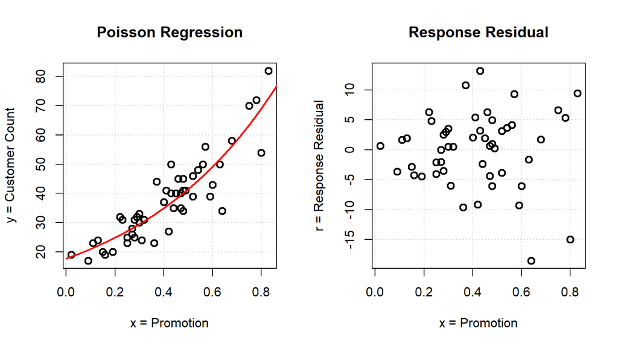

- **Pearson residual**: Attempt to standardize the response residual by dividing by its (estimated) standard error using $\text{Var}(Y_i)=\lambda_i\approx\hat{\lambda}_i$.
  $$r_i^\text{pearson} = \frac{y_i -
  \hat{\lambda}_i}{\sqrt{\hat{\lambda}_i}}$$

```r
# Pearson residual
residuals(model, type='pearson')
(y - lambda) / sqrt(lambda)
```

```
         1          2          3          4          5          6
 0.1598995 -0.7992044  0.3585748  0.4082684 -0.5952555 -0.8789148
         1          2          3          4          5          6
 0.1598995 -0.7992044  0.3585748  0.4082684 -0.5952555 -0.8789148
```

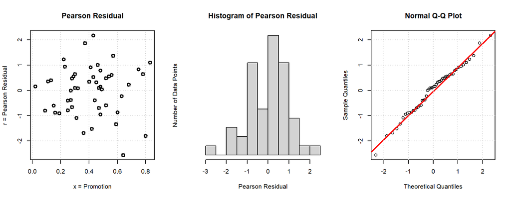

- **Deviance residual**: Inspired by the residual deviance formula
  $$D_\text{residual}
  =\sum_{i=1}^n \underbrace{2 \left(-(y_i - \hat{\lambda}_i) +
  y_i\log\,(y_i/\hat{\lambda}_i)\right)}_\text{deviance residual
  ?}$$
  Let’s define deviance residual for the $i^\text{th}$ data point to be
  $$r_i^\text{ deviance} = s_i\sqrt{2 \left(-(y_i -
  \hat{\lambda}_i) +
  y_i\log\,(y_i/\hat{\lambda}_i)\right)}\quad\quad\text{where }s_i =
  \text{sign}(y_i - \hat{\lambda}_i)$$

```r
# Deviance residual
residuals(model) # Default  Same as resid(model)
residuals(model, type='deviance')
summary(model)$deviance.resid
```

```
         1          2          3          4          5          6
 0.1589190 -0.8245491  0.3540802  0.4025608 -0.6083001 -0.9078847
         1          2          3          4          5          6
 0.1589190 -0.8245491  0.3540802  0.4025608 -0.6083001 -0.9078847
         1          2          3          4          5          6
 0.1589190 -0.8245491  0.3540802  0.4025608 -0.6083001 -0.9078847
```

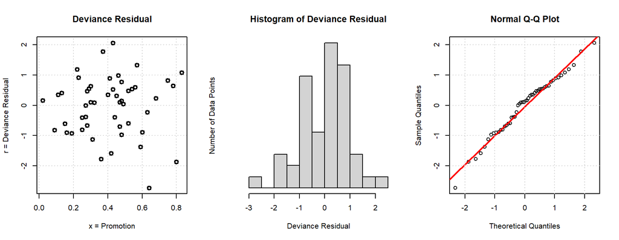

## 7.7 Rate Data and Offset

- *Example:* Let $Y_i$ be the number of pedestrians in the $i^\text{th}$ city involved in traffic accident in a year. Let $x_i$ be the average vehicle speed limit of the city and $c_i$ be the population size of the city.

```r
traffic <- data.frame(city=c(2698, 7344, 10029, 14111, 17432, 18677, 19168, 20072, 24407, 24428,
                             24509, 26191, 26245, 27300, 31796, 34888, 36349, 38826, 39503, 41199,
                             43153, 51919, 54076, 55974, 57233, 63082, 71706, 77107, 96637, 105508),
                      speed=c(37, 48, 26, 56, 25, 59, 45, 34, 23, 31,
                              33, 35, 58, 44, 48, 26, 42, 49, 39, 49,
                              22, 38, 24, 26, 32, 32, 23, 44, 41, 30),
                      accident=c(8, 25, 15, 91, 15, 112, 62, 51, 37, 38,
                                 35, 44, 150, 85, 116, 45, 110, 133, 92,
                                 173, 37, 117, 66, 64, 96, 96, 55, 253, 236, 164))
```

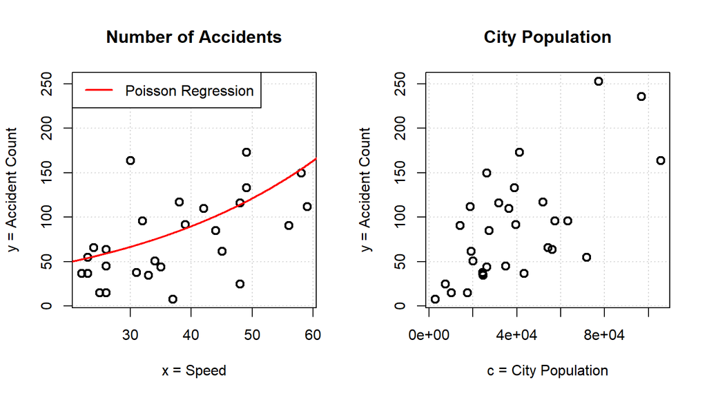

```r
model <- glm(accident ~ speed, family = poisson, data = traffic)

summary(model)
pchisq(deviance(model), df.residual(model), lower.tail=F) # X^2 goodness-of-fit test
```

```
Call:
glm(formula = accident ~ speed, family = poisson, data = traffic)

Coefficients:
            Estimate Std. Error z value Pr(>|z|)
(Intercept) 3.298721   0.074632   44.20   <2e-16 ***
speed       0.029967   0.001761   17.02   <2e-16 ***
---
Signif. codes:  0 '***' 0.001 '**' 0.01 '*' 0.05 '.' 0.1 ' ' 1

(Dispersion parameter for poisson family taken to be 1)

    Null deviance: 1206.52  on 29  degrees of freedom
Residual deviance:  919.76  on 28  degrees of freedom
AIC: 1104.8

Number of Fisher Scoring iterations: 5

[1] 1.2829e-175
```

- Intuitively, a larger city with more population $c_i$ might have more accidents $y_i$. (In statistics literature, $c_i$ is called the **exposure** i.e the number of potential occurrences of the event.) Speed limit $x_i$ is likely more related to the **rate** of accident $y_i / c_i$ instead of the count of accident $y_i$ itself.

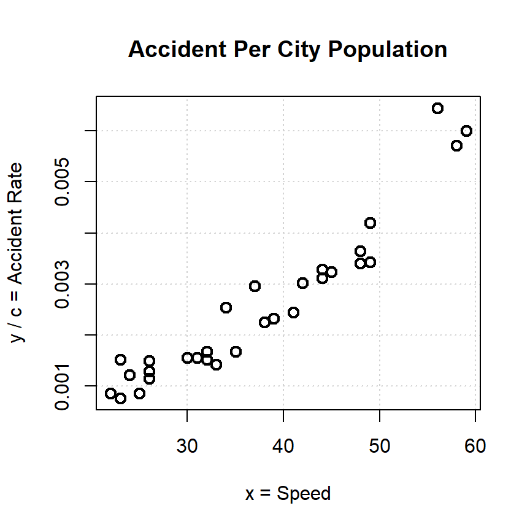

- Let’s consider the model equation with log link function as follows:
  $$\mathbb{E}(Y_i) =
  \underbrace{\lambda_i}_\text{intensity}
  = \underbrace{c_i}_\text{exposure} \times \underbrace{e^{\beta_0 +
  \beta_1 x_i}}_\text{rate of occurrence}$$
  The corresponding Poisson regression model is
  $$Y_i\sim\text{Poisson}\big(\lambda_i =
  c_ie^{\beta_0 + \beta_1 x_i}\big)\quad\text{for }i=1,\dotsc,n$$
  Rewriting the model equation as
  $$\log\mathbb{E}(Y_i) =
  \underbrace{\log(c_i)}_\text{constant offset} +
  \underbrace{\beta_0}_\text{intercept} + \beta_1 x_i$$
- The constant **offset** term (which is typically the logarithm of exposure) is part of the observed data points and not another unknown model intercept parameter (such as $\beta_0$) to be estimated.
- In R, use `glm(..., offset = ..., family=poisson)` or `glm(y ~ offset(...) + ..., family=poisson)` to specify the offset.

```r
model.o <- glm(accident ~ speed, offset = log(city), family = poisson, data = traffic)
# Same as glm(accident ~ offset(log(city)) + speed, family = poisson, data = traffic)

# Offset
model.o$offset

summary(model.o)
pchisq(deviance(model.o), df.residual(model.o), lower.tail=F) # X^2 goodness-of-fit test
```

```
[1] 7.900266 8.901639 9.213236 9.554710 9.766063 9.835048

Call:
glm(formula = accident ~ speed, family = poisson, data = traffic,
    offset = log(city))

Coefficients:
             Estimate Std. Error z value Pr(>|z|)
(Intercept) -8.035130   0.079980 -100.46   <2e-16 ***
speed        0.050731   0.001896   26.76   <2e-16 ***
---
Signif. codes:  0 '***' 0.001 '**' 0.01 '*' 0.05 '.' 0.1 ' ' 1

(Dispersion parameter for poisson family taken to be 1)

    Null deviance: 739.074  on 29  degrees of freedom
Residual deviance:  33.975  on 28  degrees of freedom
AIC: 219.05

Number of Fisher Scoring iterations: 4

[1] 0.201698
```

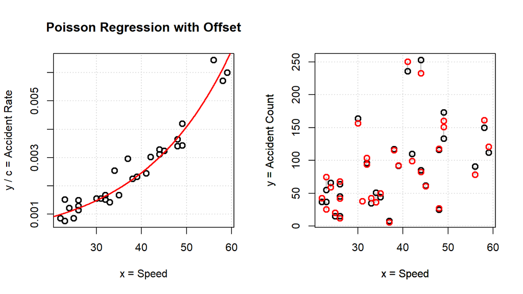

- If we do not identify the `offset()` explicitly in R’s `glm()`, then $\log c_i$ is treated as just another explanatory variable $x_{i2}$ with its own model parameter $\beta_2$ to be estimated. The model equation becomes
  $$\mathbb{E}(Y_i) =
  c_i^{\beta_2} \times e^{\beta_0 + \beta_1 x_i}$$

```r
model.c <- glm(accident ~ speed + log(city), family = poisson, data = traffic)

summary(model.c)
```

```
Call:
glm(formula = accident ~ speed + log(city), family = poisson,
    data = traffic)

Coefficients:
             Estimate Std. Error z value Pr(>|z|)
(Intercept) -7.721881   0.419399  -18.41   <2e-16 ***
speed        0.050079   0.002075   24.14   <2e-16 ***
log(city)    0.973113   0.035363   27.52   <2e-16 ***
---
Signif. codes:  0 '***' 0.001 '**' 0.01 '*' 0.05 '.' 0.1 ' ' 1

(Dispersion parameter for poisson family taken to be 1)

    Null deviance: 1206.525  on 29  degrees of freedom
Residual deviance:   33.399  on 27  degrees of freedom
AIC: 220.47

Number of Fisher Scoring iterations: 4
```

- If $\beta_2\neq 1$, then it means the number of accidents do not increase exactly proportional to the city’s population size. Let’s do a Wald $z$-test to decide.
  $$H_0: \beta_2 = 1\quad\quad\text{vs}\quad\quad
  H_a: \beta_2\neq 1$$
  The $z$-test statistic is
  $$z_2 = \frac{\hat{\beta}_2 -
  1}{\text{s.e.}(\hat{\beta}_2)}$$

```r
# Step 1: Extract standard error for b2
C <- vcov(model.c) # Same as summary(model.c)$cov.scaled and $cov.unscaled
(s.e.b2 <- sqrt(diag(C)[3]))

# Step 2: Compute z-statistic for H0: b2 = 1
b2 <- coef(model.c)[3]
(z.stat <- (b2 - 1) / s.e.b2)

# Step 3: Compute (two-sided) p-value using reference N(0,1) distribution
(p.value <- 2 * pnorm(abs(z.stat), lower.tail = FALSE)) # Large p-value so cannot reject H0
```

```
 log(city)
0.03536323
 log(city)
-0.7603051
log(city)
0.4470722
```